# NCDB Acoustic 2015

All

Jason Brant

May 21, 2018

**Note: To hide the code from this document, click the button in the upper right corner.**

```r
col.width <- c(37, 10, 1, 1, 3, 1, 2, 1, 2, 1, 1, 1, 1, 1, 1, 8, 2, 2, 2, 4, 4, 1, 4, 1, 1, 1, 3, 2, 2, 8,
               2, 5, 5, 5, 4, 5, 5, 5, 4, 2, 1, 2, 1, 3, 1, 1, 1, 1, 1, 1, 3, 3, 3, 3, 3, 3, 3, 3, 3, 3, 3,
               3, 3, 3, 3, 3, 3, 3, 3, 3, 3, 3, 3, 3, 3, 6, 8, 8, 8, 2, 1, 1, 1, 1, 8, 1, 1, 8, 1, 1, 2,
               2, 5, 2, 5, 3, 1, 3, 1, 8, 8, 2, 8, 2, 8, 2, 2, 1, 8, 1, 1, 1, 1, 1, 8, 1, 2, 2, 2, 2, 2,
               1, 1, 1, 2, 1)
col.names.abr <- c("PUF_CASE_ID", "PUF_FACILITY_ID", "FACILITY_TYPE_CD",  "FACILITY_LOCATION_CD", "AGE", "SEX", "RACE",
                   "SPANISH_HISPANIC_ORIGIN", "INSURANCE_STATUS", "MED_INC_QUAR_00", "NO_HSD_QUAR_00", "UR_CD_03",
                   "MED_INC_QUAR_12", "NO_HSD_QUAR_12", "UR_CD_13", "CROWFLY", "CDCC_TOTAL", "SEQUENCE_NUMBER",
                   "CLASS_OF_CASE", "YEAR_OF_DIAGNOSIS", "PRIMARY_SITE",  "LATERALITY", "HISTOLOGY", "BEHAVIOR",
                   "GRADE", "DIAGNOSTIC_CONFIRMATION", "TUMOR_SIZE", "REGIONAL_NODES_POSITIVE",
                   "REGIONAL_NODES_EXAMINED", "DX_STAGING_PROC_DAYS", "RX_SUMM_DXSTG_PROC", "TNM_CLIN_T",
                   "TNM_CLIN_N", "TNM_CLIN_M", "TNM_CLIN_STAGE_GROUP", "TNM_PATH_T", "TNM_PATH_N", "TNM_PATH_M",
                   "TNM_PATH_STAGE_GROUP", "TNM_EDITION_NUMBER", "ANALYTIC_STAGE_GROUP", "CS_METS_AT_DX",
                   "CS_METS_EVAL", "CS_EXTENSION", "CS_TUMOR_SIZEEXT_EVAL", "CS_METS_DX_BONE",
                   "CS_METS_DX_BRAIN", "CS_METS_DX_LIVER", "CS_METS_DX_LUNG", "LYMPH_VASCULAR_INVASION",
                   "CS_SITESPECIFIC_FACTOR_1", "CS_SITESPECIFIC_FACTOR_2", "CS_SITESPECIFIC_FACTOR_3",
                   "CS_SITESPECIFIC_FACTOR_4", "CS_SITESPECIFIC_FACTOR_5", "CS_SITESPECIFIC_FACTOR_6",
                   "CS_SITESPECIFIC_FACTOR_7", "CS_SITESPECIFIC_FACTOR_8", "CS_SITESPECIFIC_FACTOR_9",
                   "CS_SITESPECIFIC_FACTOR_10", "CS_SITESPECIFIC_FACTOR_11", "CS_SITESPECIFIC_FACTOR_12",
                   "CS_SITESPECIFIC_FACTOR_13", "CS_SITESPECIFIC_FACTOR_14", "CS_SITESPECIFIC_FACTOR_15",
                   "CS_SITESPECIFIC_FACTOR_16", "CS_SITESPECIFIC_FACTOR_17", "CS_SITESPECIFIC_FACTOR_18",
                   "CS_SITESPECIFIC_FACTOR_19", "CS_SITESPECIFIC_FACTOR_20", "CS_SITESPECIFIC_FACTOR_21",
                   "CS_SITESPECIFIC_FACTOR_22", "CS_SITESPECIFIC_FACTOR_23", "CS_SITESPECIFIC_FACTOR_24",
                   "CS_SITESPECIFIC_FACTOR_25", "CS_VERSION_LATEST", "DX_RX_STARTED_DAYS",
                   "DX_SURG_STARTED_DAYS", "DX_DEFSURG_STARTED_DAYS", "RX_SUMM_SURG_PRIM_SITE",
                   "RX_HOSP_SURG_APPR_2010", "RX_SUMM_SURGICAL_MARGINS", "RX_SUMM_SCOPE_REG_LN_SUR",
                   "RX_SUMM_SURG_OTH_REGDIS", "SURG_DISCHARGE_DAYS", "READM_HOSP_30_DAYS",
                   "REASON_FOR_NO_SURGERY", "DX_RAD_STARTED_DAYS", "RX_SUMM_RADIATION", "RAD_LOCATION_OF_RX",
                   "RAD_TREAT_VOL", "RAD_REGIONAL_RX_MODALITY", "RAD_REGIONAL_DOSE_CGY",
                   "RAD_BOOST_RX_MODALITY", "RAD_BOOST_DOSE_CGY", "RAD_NUM_TREAT_VOL",
                   "RX_SUMM_SURGRAD_SEQ", "RAD_ELAPSED_RX_DAYS", "REASON_FOR_NO_RADIATION",
                   "DX_SYSTEMIC_STARTED_DAYS", "DX_CHEMO_STARTED_DAYS", "RX_SUMM_CHEMO",
                   "DX_HORMONE_STARTED_DAYS", "RX_SUMM_HORMONE", "DX_IMMUNO_STARTED_DAYS",
                   "RX_SUMM_IMMUNOTHERAPY", "RX_SUMM_TRNSPLNT_ENDO", "RX_SUMM_SYSTEMIC_SUR_SEQ",
                   "DX_OTHER_STARTED_DAYS", "RX_SUMM_OTHER", "PALLIATIVE_CARE", "RX_SUMM_TREATMENT_STATUS",
                   "PUF_30_DAY_MORT_CD", "PUF_90_DAY_MORT_CD", "DX_LASTCONTACT_DEATH_MONTHS",
                   "PUF_VITAL_STATUS", "RX_HOSP_SURG_PRIM_SITE", "RX_HOSP_CHEMO", "RX_HOSP_IMMUNOTHERAPY",
                   "RX_HOSP_HORMONE", "RX_HOSP_OTHER", "PUF_MULT_SOURCE", "REFERENCE_DATE_FLAG",
                   "RX_SUMM_SCOPE_REG_LN_2012", "RX_HOSP_DXSTG_PROC", "PALLIATIVE_CARE_HOSP")
#Read in data for each subsite
bone.joint <- read_fwf('I:/Brant/Research/NCDB/Data/Data_2017/NCDB_PUF_DATA_Nov-07-2017/NCDBPUF_BoneJont.3.2015.0.dat',
                       fwf_widths(col.width, col_names = col.names.abr),
                       col_types = cols(.default = col_character()))
brain <- read_fwf('I:/Brant/Research/NCDB/Data/Data_2017/NCDB_PUF_DATA_Nov-07-2017/NCDBPUF_Brain.3.2015.0.dat',
                       fwf_widths(col.width, col_names = col.names.abr),
                       col_types = cols(.default = col_character()))
cns <- read_fwf('I:/Brant/Research/NCDB/Data/Data_2017/NCDB_PUF_DATA_Nov-07-2017/NCDBPUF_CNS.3.2015.0.dat',
                       fwf_widths(col.width, col_names = col.names.abr),
                       col_types = cols(.default = col_character()))
gum.ot.mth <- read_fwf('I:/Brant/Research/NCDB/Data/Data_2017/NCDB_PUF_DATA_Nov-07-2017/NCDBPUF_GumOtMth.3.2015.0.dat',
                       fwf_widths(col.width, col_names = col.names.abr),
                       col_types = cols(.default = col_character()))
hypophar <- read_fwf('I:/Brant/Research/NCDB/Data/Data_2017/NCDB_PUF_DATA_Nov-07-2017/NCDBPUF_Hypophar.3.2015.0.dat',
                       fwf_widths(col.width, col_names = col.names.abr),
                       col_types = cols(.default = col_character()))
larynx <- read_fwf('I:/Brant/Research/NCDB/Data/Data_2017/NCDB_PUF_DATA_Nov-07-2017/NCDBPUF_Larynx.3.2015.0.dat',
                       fwf_widths(col.width, col_names = col.names.abr),
                       col_types = cols(.default = col_character()))
lip <- read_fwf('I:/Brant/Research/NCDB/Data/Data_2017/NCDB_PUF_DATA_Nov-07-2017/NCDBPUF_Lip.3.2015.0.dat',
                       fwf_widths(col.width, col_names = col.names.abr),
                       col_types = cols(.default = col_character()))
melanoma <- read_fwf('I:/Brant/Research/NCDB/Data/Data_2017/NCDB_PUF_DATA_Nov-07-2017/NCDBPUF_Melanoma.3.2015.0.dat',
                       fwf_widths(col.width, col_names = col.names.abr),
                       col_types = cols(.default = col_character()))
fom <- read_fwf('I:/Brant/Research/NCDB/Data/Data_2017/NCDB_PUF_DATA_Nov-07-2017/NCDBPUF_MouthFlr.3.2015.0.dat',
                       fwf_widths(col.width, col_names = col.names.abr),
                       col_types = cols(.default = col_character()))
nasal <- read_fwf('I:/Brant/Research/NCDB/Data/Data_2017/NCDB_PUF_DATA_Nov-07-2017/NCDBPUF_Nasal.3.2015.0.dat',
                       fwf_widths(col.width, col_names = col.names.abr),
                       col_types = cols(.default = col_character()))
nasophar <- read_fwf('I:/Brant/Research/NCDB/Data/Data_2017/NCDB_PUF_DATA_Nov-07-2017/NCDBPUF_Nasophar.3.2015.0.dat',
                       fwf_widths(col.width, col_names = col.names.abr),
                       col_types = cols(.default = col_character()))
orophar <- read_fwf('I:/Brant/Research/NCDB/Data/Data_2017/NCDB_PUF_DATA_Nov-07-2017/NCDBPUF_Orophary.3.2015.0.dat',
                       fwf_widths(col.width, col_names = col.names.abr),
                       col_types = cols(.default = col_character()))
oth.endo <- read_fwf('I:/Brant/Research/NCDB/Data/Data_2017/NCDB_PUF_DATA_Nov-07-2017/NCDBPUF_OtEndocr.3.2015.0.dat',
                       fwf_widths(col.width, col_names = col.names.abr),
                       col_types = cols(.default = col_character()))
skin <- read_fwf('I:/Brant/Research/NCDB/Data/Data_2017/NCDB_PUF_DATA_Nov-07-2017/NCDBPUF_OtSkin.3.2015.0.dat',
                       fwf_widths(col.width, col_names = col.names.abr),
                       col_types = cols(.default = col_character()))
pharynx <- read_fwf('I:/Brant/Research/NCDB/Data/Data_2017/NCDB_PUF_DATA_Nov-07-2017/NCDBPUF_Pharynx.3.2015.0.dat',
                       fwf_widths(col.width, col_names = col.names.abr),
                       col_types = cols(.default = col_character()))
saliv.gland <- read_fwf('I:/Brant/Research/NCDB/Data/Data_2017/NCDB_PUF_DATA_Nov-07-2017/NCDBPUF_SalivGld.3.2015.0.dat',
                       fwf_widths(col.width, col_names = col.names.abr),
                       col_types = cols(.default = col_character()))
thyroid <- read_fwf('I:/Brant/Research/NCDB/Data/Data_2017/NCDB_PUF_DATA_Nov-07-2017/NCDBPUF_Thyroid.3.2015.0.dat',
                       fwf_widths(col.width, col_names = col.names.abr),
                       col_types = cols(.default = col_character()))
tongue <- read_fwf('I:/Brant/Research/NCDB/Data/Data_2017/NCDB_PUF_DATA_Nov-07-2017/NCDBPUF_Tongue.3.2015.0.dat',
                       fwf_widths(col.width, col_names = col.names.abr),
                       col_types = cols(.default = col_character()))
tonsil <- read_fwf('I:/Brant/Research/NCDB/Data/Data_2017/NCDB_PUF_DATA_Nov-07-2017/NCDBPUF_Tonsil.3.2015.0.dat',
                       fwf_widths(col.width, col_names = col.names.abr),
                       col_types = cols(.default = col_character()))
trach.med <- read_fwf('I:/Brant/Research/NCDB/Data/Data_2017/NCDB_PUF_DATA_Nov-07-2017/NCDBPUF_TrachMed.3.2015.0.dat',
                       fwf_widths(col.width, col_names = col.names.abr),
                       col_types = cols(.default = col_character()))
#Combine data for all subsites
dat <- bind_rows(bone.joint, brain, cns, gum.ot.mth, hypophar, larynx, lip, melanoma, fom, nasal, nasophar, orophar,
                 oth.endo, skin, pharynx, saliv.gland, thyroid, tongue, tonsil, trach.med)
rm(bone.joint, brain, cns, gum.ot.mth, hypophar, larynx, lip, melanoma, fom, nasal, nasophar, orophar,
                 oth.endo, skin, pharynx, saliv.gland, thyroid, tongue, tonsil, trach.med)
prim_site_text <- data_frame(PRIMARY_SITE = c("C030", "C031", "C062", "C039", "C050", "C051", "C052", "C058", "C059", "C068",
               "C069", "C060", "C061", "C129", "C130", "C131", "C132", "C138", "C139", "C320",
               "C321", "C322", "C323", "C328", "C329", "C000", "C003", "C001", "C004", "C006",
               "C002", "C005", "C008", "C009", "C440", "C442", "C443", "C444", "C445", "C446",
               "C447", "C448", "C449", "C441", "C040", "C041", "C048", "C049", "C300", "C301",
               "C310", "C311", "C312", "C313", "C318", "C319", "C110", "C111", "C112", "C113",
               "C118", "C119", "C090", "C091", "C098", "C099", "C100", "C102", "C103", "C104",
               "C108", "C109", "C101", "C140", "C142", "C148", "C079", "C080", "C081", "C088",
               "C089", "C739", "C019", "C024", "C020", "C021", "C022", "C023", "C028", "C029"),
               SITE_TEXT = c("C03.0: Gum, upper", "C03.1 Gum, lower", "C06.2 Retromolar area", "C03.9 Gum, NOS",
               "C05.0 Hard Palate", "C05.1 Soft Palate", "C05.2 Uvula", "C05.8 Overlapping lesion of palate",
               "C05.9 Palate NOS", "C06.8 Overlapping lesion of other an unspecified parts of mouth",
               "C06.9 Mouth, NOS", "C06.0 Buccal mucosa", "C06.1 Vestibule of mouth", "C12.9  Pyriform sinus",
               "C13.0  Postcricoid region", "C13.1  Hypopharyngeal aspect of aryepiglottic fold",
               "C13.2  Posterior wall of hypopharynx", "C13.8  Overlapping lesion of hypopharynx",
               "C13.9  Hypopharynx, NOS (laryngopharynx)", "C32.0  Glottis", "C32.1  Supraglottis",
               "C32.2  Subglottis", "C32.3  Laryngeal cartilage", "C32.8  Overlapping lesion of larynx",
               "C32.9  Larynx, NOS", "C00.0  External upper lip (vermilion)", "C00.3  Mucosa of upper lip",
               "C00.1  External lower lip (vermilion)", "C00.4  Mucosa of lower lip", "C00.6  Commissure of lip",
               "C00.2  External lip, NOS (vermilion)", "C00.5  Mucosa of lip, NOS", "C00.8  Overlapping lesion of lip",
               "C00.9  Lip, NOS (excludes skin of lip C44.0)", "C44.0  Skin of lip, NOS", "C44.2  External ear",
               "C44.3  Skin of other and unspecified parts of face", "C44.4  Skin of scalp and neck",
               "C44.5  Skin of trunk", "C44.6  Skin of upper limb and shoulder", "C44.7  Skin of lower limb and hip",
               "C44.8  Overlapping lesion of skin", "C44.9  Skin, NOS", "C44.1 Eyelid",
```

```r
               "C04.0  Anterior floor of mouth", "C04.1  Lateral floor of mouth", "C04.8  Overlapping lesion of floor of mouth",
               "C04.9  Floor of mouth, NOS", "C30.0  Nasal cavity (excluding nose, NOS C76.0)", "C30.1  Middle ear",
               "C31.0  Maxillary sinus", "C31.1  Ethmoid sinus", "C31.2  Frontal sinus", "C31.3  Sphenoid sinus",
               "C31.8  Overlapping lesion of accessory sinuses", "C31.9  Accessory sinus, NOS",
               "C11.0  Superior wall of nasopharynx", "C11.1  Posterior wall of nasopharynx (excluding pharyngeal tonsil)",
               "C11.2  Lateral wall of nasopharynx", "C11.3  Anterior wall of nasopharynx",
               "C11.8  Overlapping lesion of nasopharynx", "C11.9  Nasopharynx, NOS", "C09.0  Tonsillar fossa",
               "C09.1  Tonsillar pillar", "C09.8  Overlapping lesion of tonsil",
               "C09.9  Tonsil, NOS (excluding lingual tonsil C02.4)", "C10.0  Vallecula",
               "C10.2  Lateral wall of oropharynx", "C10.3  Posterior wall of oropharynx",
               "C10.4  Branchial cleft (site of neoplasm)", "C10.8  Overlapping lesion of oropharynx",
               "C10.9  Oropharynx, NOS", "C10.1  Anterior surface of epiglottis", "C14.0  Pharynx, NOS",
               "C14.2  Waldeyer ring", "C14.8  Overlapping lesion of lip, oral cavity", "C07.9  Parotid gland",
               "C08.0  Submandibular gland", "C08.1  Sublingual gland", "C08.8  Overlapping lesion of major salivary glands",
               "C08.9  Major salivary gland, NOS", "C73.9  Thyroid gland", "C01.9  Base of tongue, NOS",
               "C02.4  Lingual tonsil", "C02.0  Dorsal surface of tongue, NOS", "C02.1  Border of tongue (Tip)",
               "C02.2  Ventral surface of tongue, NOS", "C02.3  Anterior 2/3 of tongue, NOS",
               "C02.8  Overlapping lesion of tongue", "C02.9  Tongue, NOS"),
               CS_GROUP = c("gum_upper", "gum_lower", "gum_lower", "gum_nos", "hard_palate", "soft_palate",
             "soft_palate", "other_mouth", "other_mouth", "other_mouth", "other_mouth",
             "buccal", "buccal", "hypopharynx", "hypopharynx", "hypopharynx", "hypopharynx",
             "hypopharynx", "hypopharynx", "glottis", "supraglot", "subglot", "lx_oth",
             "lx_oth", "lx_oth", "up_lip", "up_lip", "low_lip", "low_lip", "low_lip",
             "lip_oth", "lip_oth", "lip_oth", "lip_oth", "skin", "skin", "skin", "skin",
             "skin", "skin", "skin", "skin", "skin", "eyelid", "fom", "fom", "fom", "fom",
             "nasal_cavity", "mid_ear", "max_sin", "eth_sin", "oth_sin", "oth_sin",
             "oth_sin", "oth_sin", "np", "np", "np", "np", "np", "np", "op",
             "op", "op", "op", "op", "op", "op", "op", "op", "op", "ant_epi",
             "oth_phary", "oth_phary", "oth_phary", "parotid", "smglnd",
             "glnd_oth", "glnd_oth", "glnd_oth", "thyroid", "bot_lt",
             "bot_lt", "tongue_oth", "tongue_oth", "tongue_oth", "tongue_oth",
             "tongue_oth", "tongue_oth"))
dat <- merge(dat, prim_site_text, by = "PRIMARY_SITE", all.x = TRUE)
rm(prim_site_text)
fact_vars <- c("PRIMARY_SITE", "FACILITY_TYPE_CD", "FACILITY_LOCATION_CD", "SEX", "RACE", "SPANISH_HISPANIC_ORIGIN",
               "INSURANCE_STATUS", "MED_INC_QUAR_00", "NO_HSD_QUAR_00", "UR_CD_03", "MED_INC_QUAR_12",
               "NO_HSD_QUAR_12", "UR_CD_13", "CDCC_TOTAL", "SEQUENCE_NUMBER", "CLASS_OF_CASE",
               "YEAR_OF_DIAGNOSIS", "LATERALITY", "HISTOLOGY", "BEHAVIOR",
               "GRADE", "DIAGNOSTIC_CONFIRMATION", "REGIONAL_NODES_POSITIVE", "REGIONAL_NODES_EXAMINED",
               "RX_SUMM_DXSTG_PROC", "TNM_CLIN_T",
               "TNM_CLIN_N", "TNM_CLIN_M", "TNM_CLIN_STAGE_GROUP", "TNM_PATH_T", "TNM_PATH_N",
               "TNM_PATH_M", "TNM_PATH_STAGE_GROUP", "TNM_EDITION_NUMBER", "ANALYTIC_STAGE_GROUP",
               "CS_METS_AT_DX", "CS_METS_EVAL", "CS_EXTENSION", "CS_TUMOR_SIZEEXT_EVAL", "CS_METS_DX_BONE",
               "CS_METS_DX_BRAIN", "CS_METS_DX_LIVER", "CS_METS_DX_LUNG", "LYMPH_VASCULAR_INVASION",
               "CS_VERSION_LATEST", "RX_SUMM_SURG_PRIM_SITE", "RX_HOSP_SURG_APPR_2010", "RX_SUMM_SURGICAL_MARGINS",
               "RX_SUMM_SCOPE_REG_LN_SUR", "RX_SUMM_SURG_OTH_REGDIS", "READM_HOSP_30_DAYS", "REASON_FOR_NO_SURGERY",
               "RX_SUMM_RADIATION",
               "RAD_LOCATION_OF_RX", "RAD_TREAT_VOL", "RAD_REGIONAL_RX_MODALITY", "RAD_BOOST_RX_MODALITY",
               "RX_SUMM_SURGRAD_SEQ", "REASON_FOR_NO_RADIATION", "RX_SUMM_CHEMO", "RX_SUMM_HORMONE",
               "RX_SUMM_IMMUNOTHERAPY", "RX_SUMM_TRNSPLNT_ENDO", "RX_SUMM_SYSTEMIC_SUR_SEQ",
               "RX_SUMM_OTHER", "PALLIATIVE_CARE", "RX_SUMM_TREATMENT_STATUS", "PUF_30_DAY_MORT_CD",
               "PUF_90_DAY_MORT_CD", "RX_HOSP_SURG_PRIM_SITE", "RX_HOSP_CHEMO", "RX_HOSP_IMMUNOTHERAPY",
               "RX_HOSP_HORMONE", "RX_HOSP_OTHER", "PUF_MULT_SOURCE", "REFERENCE_DATE_FLAG",
               "RX_SUMM_SCOPE_REG_LN_2012",   'RX_HOSP_DXSTG_PROC', 'PALLIATIVE_CARE_HOSP')
dat[fact_vars] <- lapply(dat[fact_vars], as.character)
dat[fact_vars] <- lapply(dat[fact_vars], as.factor)
num_vars <- c("AGE", "CROWFLY", "TUMOR_SIZE", "DX_STAGING_PROC_DAYS", "DX_RX_STARTED_DAYS", "DX_SURG_STARTED_DAYS",
              "DX_DEFSURG_STARTED_DAYS", "SURG_DISCHARGE_DAYS", "DX_RAD_STARTED_DAYS",  "RAD_REGIONAL_DOSE_CGY",
              "RAD_BOOST_DOSE_CGY", "RAD_ELAPSED_RX_DAYS", "DX_SYSTEMIC_STARTED_DAYS", "DX_CHEMO_STARTED_DAYS",
              "DX_HORMONE_STARTED_DAYS", "DX_OTHER_STARTED_DAYS", "DX_LASTCONTACT_DEATH_MONTHS",
              "RAD_NUM_TREAT_VOL")
dat[num_vars] <- lapply(dat[num_vars], as.numeric)
```

```r
p_table <- function(tab_data, ...) {
  tab_data_2 <- deparse(substitute(tab_data))

  table_p <- do.call(CreateTableOne,
                     list(data = as.name(tab_data_2), includeNA = TRUE, ...))
  table_p_out <- print(table_p,
                       showAllLevels = TRUE,
                       printToggle = FALSE)
  kable(table_p_out,
        align = "c")
}
```

```r
f_plot <- function(test_var, data_imp){

        cat("_________________________________________________")
        cat("\n")
        cat("   \n##", test_var)
        cat("\n")
        cat("_________________________________________________")
        cat("\n")

        f <- as.formula(paste(as.name(test_var),
                              "AGE + SEX + T_SIZE + FACILITY_TYPE_F + FACILITY_LOCATION_F + YEAR_OF_DIAGNOSIS",
                              sep = " ~ " ))

        data_imp_2 <- deparse(substitute(data_imp))

        fit_fn <- do.call("glm",
                       list(formula = f,
                            data = as.name(data_imp_2),
                            family = "binomial"))

        print(summary(fit_fn))

        or <- as.data.frame(exp(coefficients(fit_fn)))
        or$Variable <- rownames(or)
        rownames(or) <- c()
        names(or) <- c('OddsRatio', 'Variable')
        ci <- as.data.frame(exp(confint(fit_fn)))
        ci$Variable <- rownames(ci)
        rownames(ci) <- c()
        p_val_list <- tidy(fit_fn) %>%
        select(term, p.value) %>%
        rename(Variable = term) %>%
        mutate(p.value = round(p.value, 4))
        p_val_list$p.value <- as.character(p_val_list$p.value)
        p_val_list$p.value[p_val_list$p.value == "0"] <- "< 0.0001"
        all <- full_join(or, ci, by = 'Variable')
        all <- full_join(all, p_val_list, by = "Variable")
        names(all) <- c('OddsRatio', 'Variable', 'Lower', 'Upper', "p_value")
        all <- na.omit(all)
        all <- all %>%
        filter(Variable != '(Intercept)')
        text <- cbind(c("Variable", as.character(all$Variable)),
              c("Odds Ratio", as.character(round(all$OddsRatio, 2))),
              c("Lower CI", as.character(round(all$Lower, 2))),
              c("Upper CI", as.character(round(all$Upper, 2))),
              c("p Value", all$p_value))
        forestplot(text,
           mean = c(NA, all$OddsRatio),
           lower = c(NA, all$Lower),
           upper = c(NA, all$Upper),
           new_page =   TRUE, zero = 1,
           clip = c(0.1, 100),
           hrzl_lines = list("2" = gpar(col="#444444")),
           vertices = TRUE,
           graph.pos = 2,
           xlab = "Odds Ratio (log)",
           align = "c",
           txt_gp = fpTxtGp(cex = 0.7),
           xticks = getTicks(low = all$Lower,
                             high = all$Upper,
                             clip=c(-Inf, Inf),
                             exp=TRUE),
           boxsize = 0.1)

}
```

# Data

```r
site_code <- c("C724")
histo_code <- c("9560", "9570")
behavior_code <- c("All")
data <- dat %>%
        #filter(BEHAVIOR %in% behavior_code) %>%
        filter(PRIMARY_SITE %in% site_code) %>%
        filter(HISTOLOGY %in% histo_code) %>%
        filter(is.na(PUF_VITAL_STATUS) == FALSE) %>%
        filter(is.na(DX_LASTCONTACT_DEATH_MONTHS) == FALSE)
```

1. Site codes: C724
2. Histology codes: 9560, 9570
3. Behavior codes: All

Patients were excluded if they didn’t have values for either follow up or vital status.

Patients were excluded if they had surgery to a distant site using `RX_SUMM_SURG_OTH_REGDIS`. This was done to avoid confounding of different surgical procedures. We are only interested in surgery at the primary site. These distant site surgeries were being counted in the surgery/radiation sequence and thus to simplify analysis they were removed.

```r
data %>%
        CreateTableOne(data = .,
                     vars = c("RX_SUMM_SURG_OTH_REGDIS"),
                     includeNA = TRUE) %>%
        print(.,
              showAllLevels = TRUE)
```

```
                              level Overall
  n                                 28884
  RX_SUMM_SURG_OTH_REGDIS (%) 0     28190 (97.6)
                              1        27 ( 0.1)
                              2        16 ( 0.1)
                              3         0 ( 0.0)
                              4        11 ( 0.0)
                              5         0 ( 0.0)
                              9       640 ( 2.2)
```

```r
data <- data %>%
        filter(RX_SUMM_SURG_OTH_REGDIS == "0")
```

Whether radiation was performed was based on the `REASON_FOR_NO_RADIATION` variable. The `RADIATION_YN` variable was classified as ‘Yes’, ‘No’, or ‘Unknown’.

```r
data <- data %>%
        mutate(FACILITY_TYPE_F = fct_recode(FACILITY_TYPE_CD,
                                            "Community Cancer Program" = "1",
                                            "Comprehensive Comm Ca Program" = "2",
                                            "Academic/Research Program" = "3",
                                            "Integrated Network Ca Program" = "4",
                                            "Other" = "9")) %>%
        mutate(FACILITY_LOCATION_F = fct_recode(FACILITY_LOCATION_CD,
                                            "New England" = "1",
                                            "Middle Atlantic" = "2",
                                            "South Atlantic" = "3",
                                            "East North Central" = "4",
                                            "East South Central" = "5",
                                            "West North Central" = "6",
                                            "West South Central" = "7",
                                            "Mountain" = "8",
                                            "Pacific" = "9",
                                            "out of US" = "0")) %>%
        mutate(FACILITY_GEOGRAPHY = fct_collapse(FACILITY_LOCATION_CD,
                                                 "Northeast" = c("1", "2"),
                                                 "South" = c("3", "7"),
                                                 "Midwest" = c("4", "5", "6"),
                                                 "West" = c("8", "9"))) %>%
        mutate(AGE_F = cut(AGE, c(0, 54, 64, 74, 100))) %>%
        mutate(AGE_40 = cut(AGE, c(0, 40, 100))) %>%
        mutate(SEX_F = fct_recode(SEX,
                                "Male" = "1",
                                "Female" = "2")) %>%
        mutate(RACE_F = fct_collapse(RACE,
                                "White" = c("01"),
                                "Black" = c("02"),
                                "Asian" = c("04", "05", "06", "07", "08", "10", "11", "12", "13", "14", "15",
                                            "16", "17", "20", "21", "22", "25", "26", "27", "28", "30", "31",
                                            "32", "96", "97"),
                                "Other/Unk" = c("03", "98", "99"))) %>%
        mutate(HISPANIC = fct_collapse(SPANISH_HISPANIC_ORIGIN,
                                       "Yes" = c("1", "2", "3", "4", "5", "6", "7", "8"),
                                       "No" = c("0"),
                                       "Unknown" = c("9"))) %>%
        mutate(INSURANCE_F = fct_recode(INSURANCE_STATUS,
                                         "None" = "0",
                                         "Private" = "1",
                                         "Medicaid" = "2",
                                         "Medicare" = "3",
                                         "Other Government" = "4",
                                         "Unknown" = "9")) %>%
        mutate(INSURANCE_F = fct_relevel(INSURANCE_F,
                                         "Private")) %>%
        mutate(INCOME_F = fct_recode(MED_INC_QUAR_12,
                                      "Less than $38,000" = "1",
                                      "$38,000 - $47,999" = "2",
                                      "$48,000 - $62,999" = "3",
                                      "$63,000 +" = "4")) %>%
        mutate(EDUCATION_F = fct_recode(NO_HSD_QUAR_12,
                                        "21% or more" = "1",
                                        "13 - 20.9%" = "2",
                                        "7 - 12.9%" = "3",
                                        "Less than 7%" = "4")) %>%
        mutate(U_R_F = fct_collapse(UR_CD_13,
                                    "Metro" = c("1", "2", "3"),
                                    "Urban" = c("4", "5", "6", "7"),
                                    "Rural" = c("8", "9"))) %>%
        mutate(CLASS_OF_CASE_F = fct_collapse(CLASS_OF_CASE,
                                              All_Part_Prim = c("10", "11", "12", "13",
                                                                "14", "20", "21", "22"),
                                              Other_Facility = c("00"))) %>%
        mutate(GRADE_F = fct_recode(GRADE,
                                  "Gr I: Well Diff" = "1",
                                  "Gr II: Mod Diff" = "2",
                                  "Gr III: Poor Diff" = "3",
                                  "Gr IV: Undiff/Anaplastic" = "4",
                                  "NA/Unkown" = "9")) %>%
        mutate(HISTOLOGY_F = fct_infreq(HISTOLOGY)) %>%
        mutate(HISTOLOGY_F = factor(HISTOLOGY_F)) %>%
        mutate(HISTOLOGY_F_LIM = fct_lump(HISTOLOGY_F, prop = 0.05)) %>%
        mutate(TNM_CLIN_T = fct_recode(TNM_CLIN_T,
                                       "N_A" = "88")) %>%
        mutate(TNM_CLIN_T = fct_relevel(TNM_CLIN_T,
                                        "1")) %>%
        mutate(TNM_CLIN_N = fct_recode(TNM_CLIN_N,
                                       "N_A" = "88")) %>%
        mutate(TNM_CLIN_M = fct_recode(TNM_CLIN_M,
                                       "N_A" = "88")) %>%
        mutate(TNM_PATH_T = fct_recode(TNM_PATH_T,
                                       "N_A" = "88")) %>%
        mutate(TNM_PATH_T = fct_relevel(TNM_PATH_T,
                                        "1")) %>%
        mutate(TNM_PATH_N = fct_recode(TNM_PATH_N,
                                       "N_A" = "88")) %>%
        mutate(TNM_PATH_M = fct_recode(TNM_PATH_M,
                                       "N_A" = "88")) %>%
        mutate(TNM_CLIN_STAGE_GROUP = fct_recode(TNM_CLIN_STAGE_GROUP,
                                       "N_A" = "88")) %>%
        mutate(TNM_PATH_STAGE_GROUP = fct_recode(TNM_PATH_STAGE_GROUP,
                                       "N_A" = "88")) %>%
        mutate(MARGINS = fct_recode(RX_SUMM_SURGICAL_MARGINS,
                                    "No Residual" = "0",
                                    "Residual, NOS" = "1",
                                    "Microscopic Resid" = "2",
                                    "Macroscopic Resid" = "3",
                                    "Not evaluable" = "7",
                                    "No surg" = "8",
                                    "Unknown" = "9")) %>%
        mutate(MARGINS_YN = fct_collapse(RX_SUMM_SURGICAL_MARGINS,
                                         "Yes" = c("1", "2", "3"),
                                         "No" = c("0"),
                                         "No surg/Unk/NA" = c("7", "8", "9"))) %>%
        mutate(READM_HOSP_30_DAYS_F = fct_recode(READM_HOSP_30_DAYS,
                                                 "No_Surg_or_No_Readmit" = "0",
                                                 "Unplan_Readmit_Same" = "1",
                                                 "Plan_Readmit_Same" = "2",
                                                 "PlanUnplan_Same" = "3",
                                                 "Unknown" = "4")) %>%
        mutate(RX_SUMM_RADIATION_F = fct_recode(RX_SUMM_RADIATION,
                                                "None" = "0",
                                                "Beam Radiation" = "1",
                                                "Radioactive Implants" = "2",
                                                "Radioisotopes" = "3",
                                                "Beam + Imp or Isotopes" = "4",
                                                "Radiation, NOS" = "5",
                                                "Unknown" = "9")) %>%
        mutate(PUF_30_DAY_MORT_CD_F = fct_recode(PUF_30_DAY_MORT_CD,
                                                 "Alive_30" = "0",
                                                 "Dead_30" = "1",
                                                 "Unknown" = "9")) %>%
        mutate(PUF_90_DAY_MORT_CD_F = fct_recode(PUF_90_DAY_MORT_CD,
                                                 "Alive_90" = "0",
                                                 "Dead_90" = "1",
                                                 "Unknown" = "9")) %>%
        mutate(LYMPH_VASCULAR_INVASION_F = fct_recode(LYMPH_VASCULAR_INVASION,
                                                      "Neg_LymphVasc_Inv" = "0",
                                                      "Pos_LumphVasc_Inv" = "1",
                                                      "N_A" = "8",
                                                      "Unknown" = "9")) %>%
        mutate(RX_HOSP_SURG_APPR_2010_F = fct_recode(RX_HOSP_SURG_APPR_2010,
                                                     "No_Surg" = "0",
                                                     "Robot_Assist" = "1",
                                                     "Robot_to_Open" = "2",
                                                     "Endo_Lap" = "3",
                                                     "Endo_Lap_to_Open" = "4",
                                                     "Open_Unknown" = "5",
                                                     "Unknown" = "9")) %>%
        mutate(All = "All") %>%
        mutate(All = factor(All)) %>%
        mutate(REASON_FOR_NO_SURGERY_F = fct_recode(REASON_FOR_NO_SURGERY,
                                                    "Surg performed" = "0",
                                                    "Surg not recommended" = "1",
                                                    "No surg due to pt factors" = "2",
                                                    "No surg, pt died" = "5",
                                                    "Surg rec, not done" = "6",
                                                    "Surg rec, pt refused" = "7",
                                                    "Surg rec, unk if done" = "8",
                                                    "Unknown" = "9")) %>%
        mutate(SURGERY_YN = ifelse(REASON_FOR_NO_SURGERY == "0",
                                   "Yes",
                                   ifelse(REASON_FOR_NO_SURGERY == "9",
                                          "Ukn",
                                          "No"))) %>%
        mutate(REASON_FOR_NO_RADIATION_F = fct_recode(REASON_FOR_NO_RADIATION,
                                                    "Rad performed" = "0",
                                                    "Rad not recommended" = "1",
                                                    "No Rad due to pt factors" = "2",
                                                    "No Rad, pt died" = "5",
                                                    "Rad rec, not done" = "6",
                                                    "Rad rec, pt refused" = "7",
                                                    "Rad rec, unk if done" = "8",
                                                    "Unknown" = "9")) %>%
        mutate(RADIATION_YN = ifelse(REASON_FOR_NO_RADIATION == "0",
                                   "Yes",
                                   ifelse(REASON_FOR_NO_RADIATION == "9",
                                          "Ukn",
                                          "No"))) %>%
        mutate(SURGRAD_SEQ_F = fct_recode(RX_SUMM_SURGRAD_SEQ,
                                                   "None or Surg or Rad" = "0",
                                                   "Rad before Surg" = "2",
                                                   "Surg before Rad" = "3",
                                                   "Rad before and after Surg" = "4",
                                                   "Intraop Rad" = "5",
                                                   "Intraop Rad plus other" = "6",
                                                   "Unknown" = "9")) %>%
        mutate(SURG_RAD_SEQ = ifelse(SURGERY_YN == "Yes" & RX_SUMM_SURGRAD_SEQ == "0",
```

```r
                                     "Surg Alone",
                                     ifelse(RADIATION_YN == "Yes" & RX_SUMM_SURGRAD_SEQ == "0",
                                            "Rad Alone",
                                            ifelse(SURGERY_YN == "No" & RADIATION_YN == "No" & RX_SUMM_SURGRAD_SEQ == "0",
                                                   "No Treatement",
                                                   ifelse(RX_SUMM_SURGRAD_SEQ == "2",
                                                          "Rad then Surg",
                                                          ifelse(RX_SUMM_SURGRAD_SEQ == "3",
                                                                 "Surg then Rad",
                                                                 ifelse(RX_SUMM_SURGRAD_SEQ == "4",
                                                                        "Rad before and after Surg",
                                                                        "Other"))))))) %>%
        mutate(SURG_RAD_SEQ = fct_relevel(SURG_RAD_SEQ,
                                          "Surg Alone",
                                          "Surg then Rad",
                                          "Rad Alone")) %>%
        mutate(CHEMO_YN = fct_collapse(RX_SUMM_CHEMO,
                                       "No" = c("00", "82", "85", "86", "87"),
                                       "Yes" = c("01", "02", "03"),
                                       "Ukn" = c("88", "99"))) %>%
        mutate(SURG_RAD_SEQ_C = ifelse(SURGERY_YN == "Yes" & RX_SUMM_SURGRAD_SEQ == "0" & CHEMO_YN == "No",
                                     "Surg, No rad, No Chemo",
                                     ifelse(RADIATION_YN == "Yes" & RX_SUMM_SURGRAD_SEQ == "0" & CHEMO_YN == "No",
                                            "Rad, No Surg, No Chemo",
                                            ifelse(SURGERY_YN == "No" & RADIATION_YN == "No" & RX_SUMM_SURGRAD_SEQ == "0" & CHEMO_YN == "No",
                                                   "No Surg, No Rad, No Chemo",
                                                   ifelse(RX_SUMM_SURGRAD_SEQ == "2" & CHEMO_YN == "No",
                                                          "Rad then Surg, No Chemo",
                                                          ifelse(RX_SUMM_SURGRAD_SEQ == "3" & CHEMO_YN == "No",
                                                                 "Surg then Rad, No Chemo",
                                                                 ifelse(RX_SUMM_SURGRAD_SEQ == "4" & CHEMO_YN == "No",
                                                                        "Rad before and after Surg, No Chemo",
                                ifelse(SURGERY_YN == "Yes" & RX_SUMM_SURGRAD_SEQ == "0" & CHEMO_YN == "Yes",
                                       "Surg, No rad, Yes Chemo",
                                       ifelse(RADIATION_YN == "Yes" & RX_SUMM_SURGRAD_SEQ == "0" & CHEMO_YN == "Yes",
                                              "Rad, No Surg, Yes Chemo",
                                              ifelse(SURGERY_YN == "No" & RADIATION_YN == "No" & RX_SUMM_SURGRAD_SEQ == "0" & CHEMO_YN == "Yes",
                                                     "No Surg, No Rad, Yes Chemo",
                                                     ifelse(RX_SUMM_SURGRAD_SEQ == "2" & CHEMO_YN == "Yes",
                                                            "Rad then Surg, Yes Chemo",
                                                            ifelse(RX_SUMM_SURGRAD_SEQ == "3" & CHEMO_YN == "Yes",
                                                                   "Surg then Rad, Yes Chemo",
                                                                   ifelse(RX_SUMM_SURGRAD_SEQ == "4" & CHEMO_YN == "Yes",
                                                                          "Rad before and after Surg, Yes Chemo",
                                                                          "Other"))))))))))))) %>%
        mutate(SURG_RAD_SEQ_C = fct_infreq(SURG_RAD_SEQ_C)) %>%
        mutate(T_SIZE = as.numeric(TUMOR_SIZE)) %>%
        mutate(T_SIZE = ifelse(T_SIZE == 0,
                                "No Tumor",
                                ifelse(T_SIZE > 0 & T_SIZE < 10 | T_SIZE == 991,
                                       "< 1 cm",
                                       ifelse(T_SIZE >= 10 & T_SIZE < 20 | T_SIZE == 992,
                                              "1-2 cm",
                                              ifelse(T_SIZE >= 20 & T_SIZE < 30 | T_SIZE == 993,
                                                     "2-3 cm",
                                                     ifelse(T_SIZE >= 30 & T_SIZE < 40 | T_SIZE == 994,
                                                            "3-4 cm",
                                                            ifelse(T_SIZE >= 40 & T_SIZE < 50 | T_SIZE == 995,
                                                                   "4-5 cm",
                                                                   ifelse(T_SIZE >= 50 & T_SIZE < 60 | T_SIZE == 996,
                                                                          "5-6 cm",
                                                                          ifelse(T_SIZE >= 60 & T_SIZE <= 987 |
                                                                                         T_SIZE == 980 | T_SIZE == 989 |
                                                                                         T_SIZE == 997,
                                                                          ">6 cm",
                                                                          ifelse(T_SIZE == 988 | T_SIZE == 999,
                                                                                 "NA_unk",
                                                                                 "Microscopic focus")))))))))) %>%
        mutate(T_SIZE = factor(T_SIZE)) %>%
        mutate(T_SIZE = fct_relevel(T_SIZE,
                                     "No Tumor", "Microscopic focus", "< 1 cm", "1-2 cm", "2-3 cm", "3-4 cm",
                                       "4-5 cm", "5-6 cm", ">6 cm", "NA_unk")) %>%
        mutate(mets_at_dx = case_when(CS_METS_DX_LUNG == "1" ~ "Lung",
                                      CS_METS_DX_BONE == "1" ~ "Bone",
                                      CS_METS_DX_BRAIN == "1" ~ "Brain",
                                      CS_METS_DX_LIVER == "1" ~ "Liver",
                                      TRUE ~ "None/Other/Unk/NA"))
```

```
Unknown levels in `f`: 9Unknown levels in `f`: 0Unknown levels in `f`: 1Unknown levels in `f`: 1Unknown levels in `f`: 4Unknown levels in `f`: 5
```

```r
fact_vars_2 <- c("FACILITY_TYPE_F", "FACILITY_LOCATION_F", "AGE_F", "SEX_F", "RACE_F",
                 "HISPANIC", "INSURANCE_F", "INCOME_F", "EDUCATION_F", "U_R_F", "SITE_TEXT",
                 "CDCC_TOTAL", "CLASS_OF_CASE_F", "YEAR_OF_DIAGNOSIS", "PRIMARY_SITE", "HISTOLOGY",
                 "BEHAVIOR", "GRADE_F", "TNM_CLIN_T", "TNM_CLIN_N", "TNM_CLIN_M",
                 "TNM_CLIN_STAGE_GROUP", "TNM_PATH_T", "TNM_PATH_N", "TNM_PATH_M", "TNM_PATH_STAGE_GROUP",
                 "MARGINS", "READM_HOSP_30_DAYS_F", "RX_SUMM_RADIATION_F", "PUF_30_DAY_MORT_CD_F",
                 "PUF_90_DAY_MORT_CD_F", "LYMPH_VASCULAR_INVASION_F", "RX_HOSP_SURG_APPR_2010_F", "mets_at_dx")
data <- data %>%
        mutate_at(fact_vars_2, funs(factor(.)))
```

## Table of variables for all cases:

```r
p_table(data,
        vars = c("FACILITY_TYPE_F", "FACILITY_LOCATION_F", "FACILITY_GEOGRAPHY",  "AGE", "AGE_F", "AGE_40",
                 "SEX_F", "RACE_F", "HISPANIC", "INSURANCE_F",
                 "INCOME_F", "EDUCATION_F", "U_R_F", "CROWFLY", "CDCC_TOTAL",
                 "PRIMARY_SITE", "HISTOLOGY_F_LIM", "HISTOLOGY_F", "BEHAVIOR", "GRADE_F",
                 "DX_STAGING_PROC_DAYS", "TNM_CLIN_T", "TNM_CLIN_N", "TNM_CLIN_M",
                 "TNM_CLIN_STAGE_GROUP", "TNM_PATH_T", "TNM_PATH_N", "TNM_PATH_M",
                 "TNM_PATH_STAGE_GROUP", "DX_RX_STARTED_DAYS", "DX_SURG_STARTED_DAYS",
                 "DX_DEFSURG_STARTED_DAYS", "MARGINS", "MARGINS_YN", "SURG_DISCHARGE_DAYS",
                 "READM_HOSP_30_DAYS_F", "RX_SUMM_RADIATION_F", "PUF_30_DAY_MORT_CD_F",
                 "PUF_90_DAY_MORT_CD_F", "DX_LASTCONTACT_DEATH_MONTHS",
                 "LYMPH_VASCULAR_INVASION_F", "RX_HOSP_SURG_APPR_2010_F", "SURG_RAD_SEQ",
                 "SURG_RAD_SEQ_C", "T_SIZE", "SURGERY_YN", "RADIATION_YN", "CHEMO_YN", "mets_at_dx"))
```

|  | level | Overall |
| --- | --- | --- |
| n |  | 28190 |
| FACILITY_TYPE_F (%) | Community Cancer Program | 481 ( 1.7) |
|  | Comprehensive Comm Ca Program | 6375 ( 22.6) |
|  | Academic/Research Program | 14083 ( 50.0) |
|  | Integrated Network Ca Program | 3255 ( 11.5) |
|  | NA | 3996 ( 14.2) |
| FACILITY_LOCATION_F (%) | New England | 1135 ( 4.0) |
|  | Middle Atlantic | 4365 ( 15.5) |
|  | South Atlantic | 4652 ( 16.5) |
|  | East North Central | 4100 ( 14.5) |
|  | East South Central | 1646 ( 5.8) |
|  | West North Central | 2346 ( 8.3) |
|  | West South Central | 1750 ( 6.2) |
|  | Mountain | 1374 ( 4.9) |
|  | Pacific | 2826 ( 10.0) |
|  | NA | 3996 ( 14.2) |
| FACILITY_GEOGRAPHY (%) | Northeast | 5500 ( 19.5) |
|  | South | 6402 ( 22.7) |
|  | Midwest | 8092 ( 28.7) |
|  | West | 4200 ( 14.9) |
|  | NA | 3996 ( 14.2) |
| AGE (mean (sd)) |  | 55.32 (14.68) |
| AGE_F (%) | (0,54] | 12867 ( 45.6) |
|  | (54,64] | 7647 ( 27.1) |
|  | (64,74] | 5068 ( 18.0) |
|  | (74,100] | 2603 ( 9.2) |
|  | NA | 5 ( 0.0) |
| AGE_40 (%) | (0,40] | 4345 ( 15.4) |
|  | (40,100] | 23840 ( 84.6) |
|  | NA | 5 ( 0.0) |

[output cut: 141 more lines]

## Treatment by Year

```r
p_table(data,
        vars = c("SURG_RAD_SEQ"),
        strata = c("YEAR_OF_DIAGNOSIS"))
```

|  | level | 2004 | 2005 | 2006 | 2007 | 2008 | 2009 | 2010 | 2011 | 2012 | 2013 | 2014 | p | test |
| --- | --- | --- | --- | --- | --- | --- | --- | --- | --- | --- | --- | --- | --- | --- |
| n |  | 2068 | 2281 | 2333 | 2487 | 2555 | 2699 | 2571 | 2713 | 2802 | 2851 | 2830 |  |  |
| SURG_RAD_SEQ (%) | Surg Alone | 976 (47.2) | 1046 (45.9) | 1033 (44.3) | 1035 (41.6) | 1006 (39.4) | 1103 (40.9) | 942 (36.6) | 994 (36.6) | 992 (35.4) | 993 (34.8) | 1001 (35.4) | <0.001 |  |
|  | Surg then Rad | 32 ( 1.5) | 32 ( 1.4) | 34 ( 1.5) | 44 ( 1.8) | 38 ( 1.5) | 32 ( 1.2) | 47 ( 1.8) | 54 ( 2.0) | 56 ( 2.0) | 51 ( 1.8) | 61 ( 2.2) |  |  |
|  | Rad Alone | 693 (33.5) | 769 (33.7) | 772 (33.1) | 807 (32.4) | 827 (32.4) | 785 (29.1) | 815 (31.7) | 764 (28.2) | 767 (27.4) | 764 (26.8) | 749 (26.5) |  |  |
|  | No Treatement | 341 (16.5) | 389 (17.1) | 468 (20.1) | 553 (22.2) | 622 (24.3) | 730 (27.0) | 738 (28.7) | 874 (32.2) | 952 (34.0) | 1017 (35.7) | 1002 (35.4) |  |  |
|  | Other | 26 ( 1.3) | 45 ( 2.0) | 26 ( 1.1) | 47 ( 1.9) | 61 ( 2.4) | 49 ( 1.8) | 28 ( 1.1) | 26 ( 1.0) | 35 ( 1.2) | 25 ( 0.9) | 15 ( 0.5) |  |  |
|  | Rad then Surg | 0 ( 0.0) | 0 ( 0.0) | 0 ( 0.0) | 1 ( 0.0) | 1 ( 0.0) | 0 ( 0.0) | 1 ( 0.0) | 1 ( 0.0) | 0 ( 0.0) | 1 ( 0.0) | 2 ( 0.1) |  |  |

```
Ignoring unknown parameters: binwidth, bins, pad
```

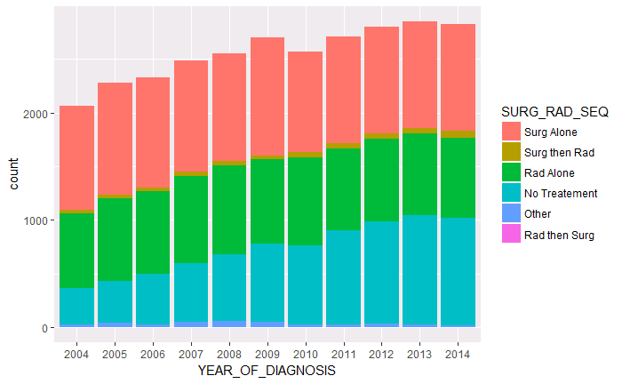

```r
data %>%
    ggplot(aes(x = YEAR_OF_DIAGNOSIS)) +
    geom_histogram(stat = "count", aes(fill = SURG_RAD_SEQ))
```

```
Ignoring unknown parameters: binwidth, bins, pad
```

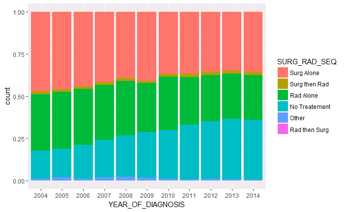

```r
data %>%
    ggplot(aes(x = YEAR_OF_DIAGNOSIS)) +
    geom_histogram(stat = "count", aes(fill = SURG_RAD_SEQ), position = "fill")
```

## Treatment by region

```r
p_table(data,
        vars = c("SURG_RAD_SEQ"),
        strata = c("FACILITY_LOCATION_F"))
```

|  | level | New England | Middle Atlantic | South Atlantic | East North Central | East South Central | West North Central | West South Central | Mountain | Pacific | p | test |
| --- | --- | --- | --- | --- | --- | --- | --- | --- | --- | --- | --- | --- |
| n |  | 1135 | 4365 | 4652 | 4100 | 1646 | 2346 | 1750 | 1374 | 2826 |  |  |
| SURG_RAD_SEQ (%) | Surg Alone | 323 (28.5) | 1071 (24.5) | 1701 (36.6) | 1760 (42.9) | 462 (28.1) | 1039 (44.3) | 786 (44.9) | 441 (32.1) | 1138 (40.3) | <0.001 |  |
|  | Surg then Rad | 17 ( 1.5) | 63 ( 1.4) | 55 ( 1.2) | 35 ( 0.9) | 27 ( 1.6) | 26 ( 1.1) | 25 ( 1.4) | 21 ( 1.5) | 64 ( 2.3) |  |  |
|  | Rad Alone | 407 (35.9) | 1854 (42.5) | 1506 (32.4) | 1151 (28.1) | 465 (28.3) | 710 (30.3) | 417 (23.8) | 481 (35.0) | 877 (31.0) |  |  |
|  | No Treatement | 370 (32.6) | 1292 (29.6) | 1330 (28.6) | 1116 (27.2) | 681 (41.4) | 554 (23.6) | 473 (27.0) | 377 (27.4) | 741 (26.2) |  |  |
|  | Other | 18 ( 1.6) | 82 ( 1.9) | 58 ( 1.2) | 38 ( 0.9) | 11 ( 0.7) | 16 ( 0.7) | 49 ( 2.8) | 54 ( 3.9) | 6 ( 0.2) |  |  |
|  | Rad then Surg | 0 ( 0.0) | 3 ( 0.1) | 2 ( 0.0) | 0 ( 0.0) | 0 ( 0.0) | 1 ( 0.0) | 0 ( 0.0) | 0 ( 0.0) | 0 ( 0.0) |  |  |

## Demographics by region

```r
p_table(data,
        vars = c("AGE_F", "RACE_F", "SEX_F", "INCOME_F", "EDUCATION_F", "INSURANCE_F", "U_R_F"),
        strata = c("FACILITY_LOCATION_F"))
```

|  | level | New England | Middle Atlantic | South Atlantic | East North Central | East South Central | West North Central | West South Central | Mountain | Pacific | p | test |
| --- | --- | --- | --- | --- | --- | --- | --- | --- | --- | --- | --- | --- |
| n |  | 1135 | 4365 | 4652 | 4100 | 1646 | 2346 | 1750 | 1374 | 2826 |  |  |
| AGE_F (%) | (0,54] | 413 (36.4) | 1604 (36.7) | 1664 (35.8) | 1546 (37.7) | 562 (34.1) | 908 (38.7) | 681 (38.9) | 469 (34.1) | 1029 (36.4) | NaN |  |
|  | (54,64] | 366 (32.2) | 1357 (31.1) | 1443 (31.0) | 1271 (31.0) | 539 (32.7) | 770 (32.8) | 527 (30.1) | 433 (31.5) | 941 (33.3) |  |  |
|  | (64,74] | 221 (19.5) | 923 (21.1) | 1031 (22.2) | 809 (19.7) | 364 (22.1) | 465 (19.8) | 369 (21.1) | 299 (21.8) | 587 (20.8) |  |  |
|  | (74,100] | 135 (11.9) | 481 (11.0) | 514 (11.0) | 474 (11.6) | 181 (11.0) | 203 ( 8.7) | 173 ( 9.9) | 173 (12.6) | 269 ( 9.5) |  |  |
|  | NA | 0 ( 0.0) | 0 ( 0.0) | 0 ( 0.0) | 0 ( 0.0) | 0 ( 0.0) | 0 ( 0.0) | 0 ( 0.0) | 0 ( 0.0) | 0 ( 0.0) |  |  |
| RACE_F (%) | White | 1037 (91.4) | 3710 (85.0) | 3996 (85.9) | 3682 (89.8) | 1527 (92.8) | 2198 (93.7) | 1524 (87.1) | 1298 (94.5) | 2350 (83.2) | <0.001 |  |
|  | Black | 20 ( 1.8) | 182 ( 4.2) | 392 ( 8.4) | 165 ( 4.0) | 88 ( 5.3) | 38 ( 1.6) | 88 ( 5.0) | 15 ( 1.1) | 51 ( 1.8) |  |  |
|  | Other/Unk | 47 ( 4.1) | 328 ( 7.5) | 166 ( 3.6) | 182 ( 4.4) | 20 ( 1.2) | 83 ( 3.5) | 108 ( 6.2) | 37 ( 2.7) | 167 ( 5.9) |  |  |
|  | Asian | 31 ( 2.7) | 145 ( 3.3) | 98 ( 2.1) | 71 ( 1.7) | 11 ( 0.7) | 27 ( 1.2) | 30 ( 1.7) | 24 ( 1.7) | 258 ( 9.1) |  |  |
| SEX_F (%) | Male | 553 (48.7) | 2059 (47.2) | 2144 (46.1) | 1889 (46.1) | 775 (47.1) | 1121 (47.8) | 803 (45.9) | 665 (48.4) | 1394 (49.3) | 0.116 |  |
|  | Female | 582 (51.3) | 2306 (52.8) | 2508 (53.9) | 2211 (53.9) | 871 (52.9) | 1225 (52.2) | 947 (54.1) | 709 (51.6) | 1432 (50.7) |  |  |
| INCOME_F (%) | Less than $38,000 | 60 ( 5.3) | 373 ( 8.5) | 741 (15.9) | 390 ( 9.5) | 527 (32.0) | 203 ( 8.7) | 289 (16.5) | 97 ( 7.1) | 189 ( 6.7) | <0.001 |  |
|  | $38,000 - $47,999 | 89 ( 7.8) | 685 (15.7) | 1051 (22.6) | 982 (24.0) | 419 (25.5) | 673 (28.7) | 418 (23.9) | 248 (18.0) | 486 (17.2) |  |  |
|  | $48,000 - $62,999 | 290 (25.6) | 1121 (25.7) | 1222 (26.3) | 1211 (29.5) | 397 (24.1) | 769 (32.8) | 468 (26.7) | 458 (33.3) | 887 (31.4) |  |  |
|  | $63,000 + | 683 (60.2) | 2151 (49.3) | 1593 (34.2) | 1494 (36.4) | 297 (18.0) | 695 (29.6) | 566 (32.3) | 552 (40.2) | 1243 (44.0) |  |  |
|  | NA | 13 ( 1.1) | 35 ( 0.8) | 45 ( 1.0) | 23 ( 0.6) | 6 ( 0.4) | 6 ( 0.3) | 9 ( 0.5) | 19 ( 1.4) | 21 ( 0.7) |  |  |
| EDUCATION_F (%) | 21% or more | 78 ( 6.9) | 403 ( 9.2) | 672 (14.4) | 244 ( 6.0) | 407 (24.7) | 82 ( 3.5) | 435 (24.9) | 80 ( 5.8) | 351 (12.4) | <0.001 |  |
|  | 13 - 20.9% | 154 (13.6) | 747 (17.1) | 1309 (28.1) | 914 (22.3) | 602 (36.6) | 395 (16.8) | 465 (26.6) | 186 (13.5) | 507 (17.9) |  |  |
|  | 7 - 12.9% | 403 (35.5) | 1755 (40.2) | 1416 (30.4) | 1528 (37.3) | 375 (22.8) | 923 (39.3) | 466 (26.6) | 425 (30.9) | 1055 (37.3) |  |  |
|  | Less than 7% | 487 (42.9) | 1428 (32.7) | 1213 (26.1) | 1392 (34.0) | 256 (15.6) | 940 (40.1) | 375 (21.4) | 664 (48.3) | 894 (31.6) |  |  |
|  | NA | 13 ( 1.1) | 32 ( 0.7) | 42 ( 0.9) | 22 ( 0.5) | 6 ( 0.4) | 6 ( 0.3) | 9 ( 0.5) | 19 ( 1.4) | 19 ( 0.7) |  |  |
| INSURANCE_F (%) | Private | 728 (64.1) | 2760 (63.2) | 2704 (58.1) | 2473 (60.3) | 889 (54.0) | 1446 (61.6) | 1066 (60.9) | 779 (56.7) | 1761 (62.3) | <0.001 |  |
|  | None | 9 ( 0.8) | 56 ( 1.3) | 114 ( 2.5) | 58 ( 1.4) | 29 ( 1.8) | 44 ( 1.9) | 68 ( 3.9) | 23 ( 1.7) | 49 ( 1.7) |  |  |
|  | Medicaid | 41 ( 3.6) | 176 ( 4.0) | 99 ( 2.1) | 133 ( 3.2) | 52 ( 3.2) | 51 ( 2.2) | 35 ( 2.0) | 44 ( 3.2) | 153 ( 5.4) |  |  |
|  | Medicare | 327 (28.8) | 1235 (28.3) | 1506 (32.4) | 1258 (30.7) | 589 (35.8) | 660 (28.1) | 514 (29.4) | 441 (32.1) | 768 (27.2) |  |  |
|  | Other Government | 6 ( 0.5) | 36 ( 0.8) | 133 ( 2.9) | 44 ( 1.1) | 62 ( 3.8) | 65 ( 2.8) | 42 ( 2.4) | 56 ( 4.1) | 42 ( 1.5) |  |  |
|  | Unknown | 24 ( 2.1) | 102 ( 2.3) | 96 ( 2.1) | 134 ( 3.3) | 25 ( 1.5) | 80 ( 3.4) | 25 ( 1.4) | 31 ( 2.3) | 53 ( 1.9) |  |  |
| U_R_F (%) | Metro | 882 (77.7) | 3917 (89.7) | 3954 (85.0) | 3324 (81.1) | 1148 (69.7) | 1551 (66.1) | 1442 (82.4) | 1087 (79.1) | 2470 (87.4) | <0.001 |  |
|  | Urban | 109 ( 9.6) | 373 ( 8.5) | 469 (10.1) | 650 (15.9) | 379 (23.0) | 627 (26.7) | 241 (13.8) | 203 (14.8) | 248 ( 8.8) |  |  |
|  | Rural | 6 ( 0.5) | 7 ( 0.2) | 58 ( 1.2) | 41 ( 1.0) | 77 ( 4.7) | 131 ( 5.6) | 24 ( 1.4) | 26 ( 1.9) | 16 ( 0.6) |  |  |
|  | NA | 138 (12.2) | 68 ( 1.6) | 171 ( 3.7) | 85 ( 2.1) | 42 ( 2.6) | 37 ( 1.6) | 43 ( 2.5) | 58 ( 4.2) | 92 ( 3.3) |  |  |

## Treatment by tumor size

```r
p_table(data,
        vars = c("SURG_RAD_SEQ"),
        strata = c("T_SIZE"))
```

|  | level | No Tumor | Microscopic focus | < 1 cm | 1-2 cm | 2-3 cm | 3-4 cm | 4-5 cm | 5-6 cm | >6 cm | NA_unk | p | test |
| --- | --- | --- | --- | --- | --- | --- | --- | --- | --- | --- | --- | --- | --- |
| n |  | 4 | 14 | 5651 | 8775 | 4784 | 2117 | 799 | 283 | 563 | 5200 |  |  |
| SURG_RAD_SEQ (%) | Surg Alone | 1 (25.0) | 5 (35.7) | 957 (16.9) | 2549 (29.0) | 2335 (48.8) | 1524 (72.0) | 602 (75.3) | 179 (63.3) | 195 (34.6) | 2774 (53.3) | <0.001 |  |
|  | Surg then Rad | 0 ( 0.0) | 0 ( 0.0) | 5 ( 0.1) | 13 ( 0.1) | 96 ( 2.0) | 148 ( 7.0) | 81 (10.1) | 35 (12.4) | 8 ( 1.4) | 95 ( 1.8) |  |  |
|  | Rad Alone | 1 (25.0) | 1 ( 7.1) | 1386 (24.5) | 3719 (42.4) | 1668 (34.9) | 226 (10.7) | 33 ( 4.1) | 26 ( 9.2) | 205 (36.4) | 1247 (24.0) |  |  |
|  | No Treatement | 2 (50.0) | 8 (57.1) | 3213 (56.9) | 2400 (27.4) | 624 (13.0) | 182 ( 8.6) | 63 ( 7.9) | 35 (12.4) | 152 (27.0) | 1007 (19.4) |  |  |
|  | Other | 0 ( 0.0) | 0 ( 0.0) | 90 ( 1.6) | 93 ( 1.1) | 60 ( 1.3) | 34 ( 1.6) | 18 ( 2.3) | 8 ( 2.8) | 3 ( 0.5) | 77 ( 1.5) |  |  |
|  | Rad then Surg | 0 ( 0.0) | 0 ( 0.0) | 0 ( 0.0) | 1 ( 0.0) | 1 ( 0.0) | 3 ( 0.1) | 2 ( 0.3) | 0 ( 0.0) | 0 ( 0.0) | 0 ( 0.0) |  |  |

```
Ignoring unknown parameters: binwidth, bins, pad
```

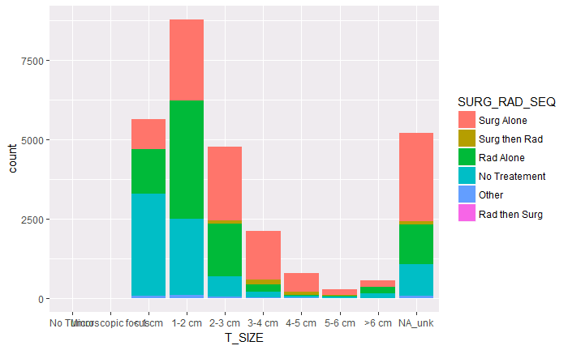

```r
data %>%
    ggplot(aes(x = T_SIZE)) +
    geom_histogram(stat = "count", aes(fill = SURG_RAD_SEQ))
```

```
Ignoring unknown parameters: binwidth, bins, pad
```

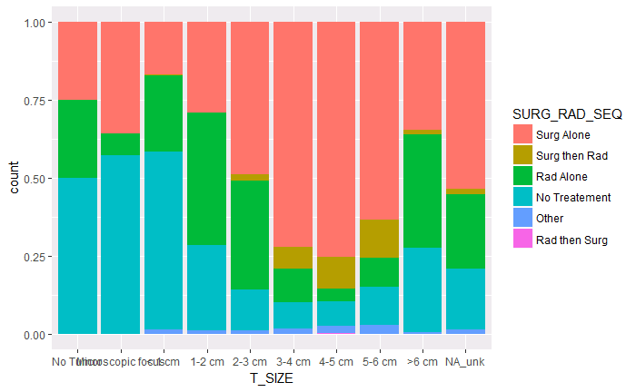

```r
data %>%
    ggplot(aes(x = T_SIZE)) +
    geom_histogram(stat = "count", aes(fill = SURG_RAD_SEQ), position = "fill")
```

# Tumor size by year

Limited to below 10 cm to exclude recording errors

```r
data <- data %>%
        mutate(TUMOR_SIZE_LIM = ifelse(TUMOR_SIZE < 100,
                                       TUMOR_SIZE,
                                        NA)) %>%
        mutate(T_SIZE_LIM = fct_recode(T_SIZE,
                                       NULL = "NA_unk"))
p_table(data,
        vars = c("TUMOR_SIZE", "TUMOR_SIZE_LIM", "T_SIZE_LIM"),
        strata = c("YEAR_OF_DIAGNOSIS"))
```

|  | level | 2004 | 2005 | 2006 | 2007 | 2008 | 2009 | 2010 | 2011 | 2012 | 2013 | 2014 | p | test |
| --- | --- | --- | --- | --- | --- | --- | --- | --- | --- | --- | --- | --- | --- | --- |
| n |  | 2068 | 2281 | 2333 | 2487 | 2555 | 2699 | 2571 | 2713 | 2802 | 2851 | 2830 |  |  |
| TUMOR_SIZE (mean (sd)) |  | 322.11 (452.61) | 312.11 (447.64) | 277.18 (430.72) | 244.88 (412.52) | 230.12 (402.30) | 205.25 (382.47) | 170.80 (354.99) | 158.97 (343.49) | 145.83 (329.07) | 145.61 (329.53) | 139.44 (322.39) | <0.001 |  |
| TUMOR_SIZE_LIM (mean (sd)) |  | 17.62 (12.12) | 18.61 (12.20) | 18.59 (13.00) | 18.16 (11.83) | 17.67 (11.94) | 18.01 (12.84) | 18.00 (13.00) | 17.99 (12.41) | 17.92 (12.39) | 17.41 (12.21) | 17.82 (12.49) | 0.085 |  |
| T_SIZE_LIM (%) | No Tumor | 0 ( 0.0) | 0 ( 0.0) | 0 ( 0.0) | 0 ( 0.0) | 0 ( 0.0) | 1 ( 0.0) | 0 ( 0.0) | 2 ( 0.1) | 0 ( 0.0) | 0 ( 0.0) | 1 ( 0.0) | <0.001 |  |
|  | Microscopic focus | 1 ( 0.0) | 1 ( 0.0) | 0 ( 0.0) | 3 ( 0.1) | 0 ( 0.0) | 0 ( 0.0) | 2 ( 0.1) | 1 ( 0.0) | 3 ( 0.1) | 3 ( 0.1) | 0 ( 0.0) |  |  |
|  | < 1 cm | 328 (15.9) | 334 (14.6) | 391 (16.8) | 423 (17.0) | 517 (20.2) | 556 (20.6) | 538 (20.9) | 598 (22.0) | 633 (22.6) | 677 (23.7) | 656 (23.2) |  |  |
|  | 1-2 cm | 603 (29.2) | 614 (26.9) | 666 (28.5) | 780 (31.4) | 731 (28.6) | 836 (31.0) | 867 (33.7) | 874 (32.2) | 906 (32.3) | 945 (33.1) | 953 (33.7) |  |  |
|  | 2-3 cm | 284 (13.7) | 381 (16.7) | 385 (16.5) | 423 (17.0) | 445 (17.4) | 443 (16.4) | 426 (16.6) | 500 (18.4) | 516 (18.4) | 482 (16.9) | 499 (17.6) |  |  |
|  | 3-4 cm | 138 ( 6.7) | 161 ( 7.1) | 167 ( 7.2) | 180 ( 7.2) | 192 ( 7.5) | 190 ( 7.0) | 198 ( 7.7) | 212 ( 7.8) | 234 ( 8.4) | 241 ( 8.5) | 204 ( 7.2) |  |  |
|  | 4-5 cm | 41 ( 2.0) | 57 ( 2.5) | 58 ( 2.5) | 68 ( 2.7) | 64 ( 2.5) | 90 ( 3.3) | 87 ( 3.4) | 75 ( 2.8) | 84 ( 3.0) | 72 ( 2.5) | 103 ( 3.6) |  |  |
|  | 5-6 cm | 18 ( 0.9) | 24 ( 1.1) | 26 ( 1.1) | 21 ( 0.8) | 22 ( 0.9) | 24 ( 0.9) | 27 ( 1.1) | 41 ( 1.5) | 22 ( 0.8) | 31 ( 1.1) | 27 ( 1.0) |  |  |
|  | >6 cm | 40 ( 1.9) | 44 ( 1.9) | 50 ( 2.1) | 40 ( 1.6) | 62 ( 2.4) | 92 ( 3.4) | 47 ( 1.8) | 41 ( 1.5) | 53 ( 1.9) | 49 ( 1.7) | 45 ( 1.6) |  |  |
|  | NA | 615 (29.7) | 665 (29.2) | 590 (25.3) | 549 (22.1) | 522 (20.4) | 467 (17.3) | 379 (14.7) | 369 (13.6) | 351 (12.5) | 351 (12.3) | 342 (12.1) |  |  |

```r
data %>%
        mutate(YEAR = as.numeric(as.character(YEAR_OF_DIAGNOSIS))) %>%
        lm(TUMOR_SIZE_LIM ~ YEAR,
              data = .) %>%
        summary()
```

```
Call:
lm(formula = TUMOR_SIZE_LIM ~ YEAR, data = .)

Residuals:
    Min      1Q  Median      3Q     Max
-17.986  -8.273  -2.871   5.899  81.244

Coefficients:
             Estimate Std. Error t value Pr(>|t|)
(Intercept) 133.48387   54.03556   2.470   0.0135 *
YEAR         -0.05749    0.02689  -2.138   0.0325 *
---
Signif. codes:  0 *** 0.001 ** 0.01 * 0.05 . 0.1   1

Residual standard error: 12.42 on 22545 degrees of freedom
  (5643 observations deleted due to missingness)
Multiple R-squared:  0.0002027, Adjusted R-squared:  0.0001584
F-statistic: 4.571 on 1 and 22545 DF,  p-value: 0.03253
```

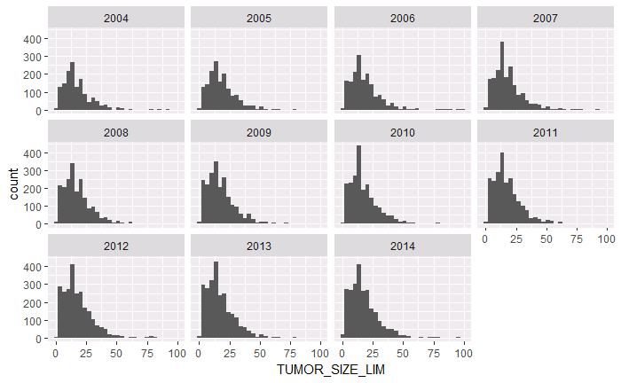

```r
data %>%
    ggplot(aes(x = TUMOR_SIZE_LIM)) +
    geom_histogram() +
    facet_wrap(~ YEAR_OF_DIAGNOSIS)
```

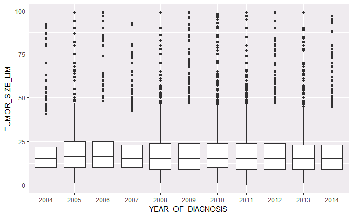

```r
data %>%
    ggplot(aes(x = YEAR_OF_DIAGNOSIS, y = TUMOR_SIZE_LIM)) +
    geom_boxplot()
```

```
Ignoring unknown parameters: binwidth, bins, pad
```

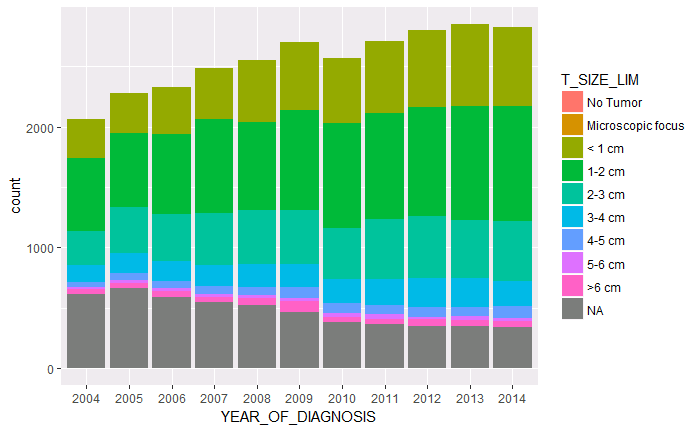

```r
data %>%
        ggplot(aes(x = YEAR_OF_DIAGNOSIS)) +
        geom_histogram(stat = "count",
                       aes(fill = T_SIZE_LIM))
```

```
Ignoring unknown parameters: binwidth, bins, pad
```

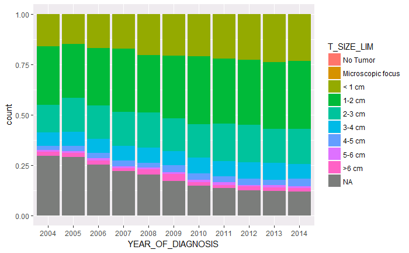

```r
data %>%
        ggplot(aes(x = YEAR_OF_DIAGNOSIS)) +
        geom_histogram(stat = "count",
                       aes(fill = T_SIZE_LIM),
                       position = "fill")
```

# Treatment models

```r
data <- data %>%
        mutate(FACILITY_LOCATION_F = fct_relevel(FACILITY_LOCATION_F,
                                             "New England")) %>%
        mutate(SURG_TX = case_when(SURGERY_YN == "Yes" ~ TRUE,
                                   SURGERY_YN == "No" ~ FALSE,
                                   TRUE ~ NA)) %>%
        mutate(YEAR_OF_DIAGNOSIS = fct_relevel(YEAR_OF_DIAGNOSIS,
                                               "2014"))
fit_surg <- glm(SURG_TX ~ AGE + SEX + CDCC_TOTAL + T_SIZE + FACILITY_TYPE_F + FACILITY_LOCATION_F +
                        YEAR_OF_DIAGNOSIS,
                family = "binomial",
                data = data)
summary(fit_surg)
```

```
Call:
glm(formula = SURG_TX ~ AGE + SEX + CDCC_TOTAL + T_SIZE + FACILITY_TYPE_F +
    FACILITY_LOCATION_F + YEAR_OF_DIAGNOSIS, family = "binomial",
    data = data)

Deviance Residuals:
    Min       1Q   Median       3Q      Max
-2.7538  -0.8017  -0.4367   0.8795   2.7182

Coefficients:
                                               Estimate Std. Error z value Pr(>|z|)
(Intercept)                                   1.4531172  1.2147751   1.196 0.231617
AGE                                          -0.0709696  0.0015969 -44.442  < 2e-16 ***
SEX2                                          0.1187358  0.0314558   3.775 0.000160 ***
CDCC_TOTAL1                                   0.8142192  0.0518702  15.697  < 2e-16 ***
CDCC_TOTAL2                                   0.5751462  0.1201214   4.788 1.68e-06 ***
CDCC_TOTAL3                                  -0.0860583  0.2142707  -0.402 0.687954
T_SIZEMicroscopic focus                      -0.2719462  1.3991489  -0.194 0.845890
T_SIZE< 1 cm                                 -1.1692474  1.2034516  -0.972 0.331260
T_SIZE1-2 cm                                 -0.4667826  1.2030809  -0.388 0.698024
T_SIZE2-3 cm                                  0.5439342  1.2032444   0.452 0.651228
T_SIZE3-4 cm                                  1.9879321  1.2044062   1.651 0.098831 .
T_SIZE4-5 cm                                  2.3800457  1.2095734   1.968 0.049106 *
T_SIZE5-6 cm                                  1.4769982  1.2150887   1.216 0.224157
T_SIZE>6 cm                                  -0.2774899  1.2075110  -0.230 0.818245
T_SIZENA_unk                                  0.7650461  1.2032867   0.636 0.524909
FACILITY_TYPE_FComprehensive Comm Ca Program  1.1364566  0.1522797   7.463 8.46e-14 ***
FACILITY_TYPE_FAcademic/Research Program      1.5410166  0.1503926  10.247  < 2e-16 ***
FACILITY_TYPE_FIntegrated Network Ca Program  1.2260301  0.1553333   7.893 2.95e-15 ***
FACILITY_LOCATION_FMiddle Atlantic           -0.2198547  0.0853294  -2.577 0.009979 **
FACILITY_LOCATION_FSouth Atlantic             0.5435366  0.0847694   6.412 1.44e-10 ***
FACILITY_LOCATION_FEast North Central         0.7638191  0.0847409   9.014  < 2e-16 ***
FACILITY_LOCATION_FEast South Central         0.0805509  0.0991381   0.813 0.416498
FACILITY_LOCATION_FWest North Central         0.8983591  0.0901677   9.963  < 2e-16 ***
FACILITY_LOCATION_FWest South Central         0.9056959  0.0952839   9.505  < 2e-16 ***
FACILITY_LOCATION_FMountain                   0.6113601  0.1020021   5.994 2.05e-09 ***
FACILITY_LOCATION_FPacific                    0.7522076  0.0892289   8.430  < 2e-16 ***
YEAR_OF_DIAGNOSIS2004                         0.4429541  0.0762697   5.808 6.33e-09 ***
YEAR_OF_DIAGNOSIS2005                         0.2690920  0.0740816   3.632 0.000281 ***
YEAR_OF_DIAGNOSIS2006                         0.2409033  0.0734078   3.282 0.001032 **
YEAR_OF_DIAGNOSIS2007                         0.1835904  0.0726315   2.528 0.011481 *
YEAR_OF_DIAGNOSIS2008                         0.0910493  0.0727809   1.251 0.210932
YEAR_OF_DIAGNOSIS2009                         0.1737611  0.0716964   2.424 0.015369 *
YEAR_OF_DIAGNOSIS2010                        -0.0004844  0.0728407  -0.007 0.994694
YEAR_OF_DIAGNOSIS2011                         0.0194780  0.0721033   0.270 0.787052
YEAR_OF_DIAGNOSIS2012                        -0.0218309  0.0714533  -0.306 0.759965
YEAR_OF_DIAGNOSIS2013                        -0.0704284  0.0716865  -0.982 0.325878
---
Signif. codes:  0 *** 0.001 ** 0.01 * 0.05 . 0.1   1

(Dispersion parameter for binomial family taken to be 1)

    Null deviance: 31836  on 23903  degrees of freedom
Residual deviance: 24520  on 23868  degrees of freedom
  (4286 observations deleted due to missingness)
AIC: 24592

Number of Fisher Scoring iterations: 5
```

```r
exp(cbind("Odds ratio" = coef(fit_surg), confint.default(fit_surg, level = 0.95)))
```

```
                                             Odds ratio      2.5 %      97.5 %
(Intercept)                                   4.2764240 0.39542338  46.2486629
AGE                                           0.9314902 0.92857932   0.9344102
SEX2                                          1.1260724 1.05874436   1.1976820
CDCC_TOTAL1                                   2.2574123 2.03919548   2.4989808
CDCC_TOTAL2                                   1.7773904 1.40454378   2.2492120
CDCC_TOTAL3                                   0.9175407 0.60288955   1.3964100
T_SIZEMicroscopic focus                       0.7618952 0.04908373  11.8264115
T_SIZE< 1 cm                                  0.3106006 0.02936449   3.2853541
T_SIZE1-2 cm                                  0.6270164 0.05932183   6.6274013
T_SIZE2-3 cm                                  1.7227713 0.16293866  18.2150819
T_SIZE3-4 cm                                  7.3004213 0.68889887  77.3642597
T_SIZE4-5 cm                                 10.8053968 1.00936911 115.6728498
T_SIZE5-6 cm                                  4.3797787 0.40473126  47.3955511
T_SIZE>6 cm                                   0.7576832 0.07106446   8.0783542
T_SIZENA_unk                                  2.1490934 0.20324309  22.7245241
FACILITY_TYPE_FComprehensive Comm Ca Program  3.1157085 2.31172448   4.1993064
FACILITY_TYPE_FAcademic/Research Program      4.6693349 3.47728772   6.2700270
FACILITY_TYPE_FIntegrated Network Ca Program  3.4076745 2.51326437   4.6203837
FACILITY_LOCATION_FMiddle Atlantic            0.8026354 0.67902508   0.9487478
FACILITY_LOCATION_FSouth Atlantic             1.7220865 1.45847536   2.0333439
FACILITY_LOCATION_FEast North Central         2.1464581 1.81798704   2.5342767
FACILITY_LOCATION_FEast South Central         1.0838840 0.89247548   1.3163437
FACILITY_LOCATION_FWest North Central         2.4555706 2.05779240   2.9302406
FACILITY_LOCATION_FWest South Central         2.4736527 2.05226276   2.9815665
FACILITY_LOCATION_FMountain                   1.8429363 1.50898874   2.2507884
FACILITY_LOCATION_FPacific                    2.1216787 1.78126224   2.5271520
YEAR_OF_DIAGNOSIS2004                         1.5573008 1.34107066   1.8083953
YEAR_OF_DIAGNOSIS2005                         1.3087756 1.13189664   1.5132950
YEAR_OF_DIAGNOSIS2006                         1.2723980 1.10188980   1.4692909
YEAR_OF_DIAGNOSIS2007                         1.2015236 1.04209736   1.3853398
YEAR_OF_DIAGNOSIS2008                         1.0953230 0.94970999   1.2632619
YEAR_OF_DIAGNOSIS2009                         1.1897712 1.03379733   1.3692777
YEAR_OF_DIAGNOSIS2010                         0.9995157 0.86653783   1.1529002
YEAR_OF_DIAGNOSIS2011                         1.0196690 0.88528846   1.1744475
YEAR_OF_DIAGNOSIS2012                         0.9784057 0.85054601   1.1254860
YEAR_OF_DIAGNOSIS2013                         0.9319945 0.80982961   1.0725882
```

# Kaplan Meier Analysis

```r
uni_var <- function(test_var, data_imp) {

        cat("_________________________________________________")
        cat("\n")
        cat("   \n##", test_var)
        cat("\n")
        cat("_________________________________________________")
        cat("\n")

        f <- as.formula(paste("Surv(DX_LASTCONTACT_DEATH_MONTHS, PUF_VITAL_STATUS == 0)",
                              as.name(test_var),
                              sep = " ~ " ))

        data_imp_2 <- deparse(substitute(data_imp))
        km_fit <- do.call("survfit", list(formula = f, data = as.name(data_imp_2)))
        print(km_fit)
        cat("\n")
        print(summary(km_fit, times = c(12, 24, 36, 48, 60, 120)))
        cat("\n")
        cat("\n")
        cat("\n")
        cat("   \n## Univariable Cox Proportional Hazard Model for: ", test_var)
        cat("\n")
        cat("\n")
        n_levels <- nlevels(data_imp[[test_var]])
        if(n_levels == 1){
                print("Only one level, no Cox model performed")
                cat("\n")
        } else {
                cox_fit <- do.call("coxph", list(formula = f, data = as.name(data_imp_2)))
                print(summary(cox_fit))
                cat("\n")

                do.call("ggforest",
                         list(model = cox_fit, data = as.name(data_imp_2)))
        }
        cat("\n")
        cat("\n")
        cat("\n")
        cat("   \n## Unadjusted Kaplan Meier Overall Survival Curve for: ", test_var)
        p <- do.call("ggsurvplot",
                     list(fit = km_fit, data = as.name(data_imp_2),
                          palette = "jco", censor = FALSE, legend = "right",
                          linetype = "strata", xlab = "Time (Months)"))
        print(p)
}
```

## All

```
_________________________________________________

## All
_________________________________________________
Call: survfit(formula = Surv(DX_LASTCONTACT_DEATH_MONTHS, PUF_VITAL_STATUS ==
    0) ~ All, data = data)

      n  events  median 0.95LCL 0.95UCL
  28190    2199      NA      NA      NA

Call: survfit(formula = Surv(DX_LASTCONTACT_DEATH_MONTHS, PUF_VITAL_STATUS ==
    0) ~ All, data = data)

 time n.risk n.event survival std.err lower 95% CI upper 95% CI
   12  25978     499    0.982 0.00081        0.980        0.983
   24  23239     308    0.970 0.00105        0.968        0.972
   36  19915     259    0.958 0.00126        0.956        0.961
   48  16726     238    0.946 0.00148        0.943        0.949
   60  13693     199    0.933 0.00170        0.930        0.937
  120   2681     624    0.856 0.00363        0.849        0.863




## Univariable Cox Proportional Hazard Model for:  All

[1] "Only one level, no Cox model performed"





## Unadjusted Kaplan Meier Overall Survival Curve for:  All
```

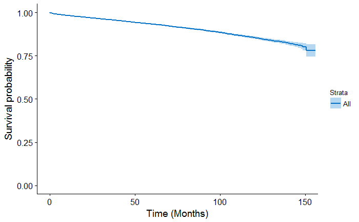

```r
uni_var(test_var = "All", data_imp = data)
```

## Facility Type

```
_________________________________________________

## FACILITY_TYPE_F
_________________________________________________
Call: survfit(formula = Surv(DX_LASTCONTACT_DEATH_MONTHS, PUF_VITAL_STATUS ==
    0) ~ FACILITY_TYPE_F, data = data)

   3996 observations deleted due to missingness
                                                  n events median 0.95LCL 0.95UCL
FACILITY_TYPE_F=Community Cancer Program        481     74     NA      NA      NA
FACILITY_TYPE_F=Comprehensive Comm Ca Program  6375    742     NA      NA      NA
FACILITY_TYPE_F=Academic/Research Program     14083    980     NA      NA      NA
FACILITY_TYPE_F=Integrated Network Ca Program  3255    326     NA      NA      NA

Call: survfit(formula = Surv(DX_LASTCONTACT_DEATH_MONTHS, PUF_VITAL_STATUS ==
    0) ~ FACILITY_TYPE_F, data = data)

3996 observations deleted due to missingness
                FACILITY_TYPE_F=Community Cancer Program
 time n.risk n.event survival std.err lower 95% CI upper 95% CI
   12    415      15    0.967 0.00841        0.951        0.984
   24    358      13    0.935 0.01186        0.912        0.959
   36    287      13    0.899 0.01514        0.869        0.929
   48    233       6    0.879 0.01689        0.846        0.912
   60    183      12    0.830 0.02099        0.790        0.872
  120     29      13    0.740 0.03176        0.680        0.805

                FACILITY_TYPE_F=Comprehensive Comm Ca Program
 time n.risk n.event survival std.err lower 95% CI upper 95% CI
   12   5774     192    0.969 0.00222        0.964        0.973
   24   5171     112    0.949 0.00284        0.944        0.955
   36   4441      83    0.933 0.00331        0.926        0.939
   48   3780      76    0.916 0.00378        0.908        0.923
   60   3092      57    0.901 0.00421        0.893        0.909
  120    560     199    0.794 0.00875        0.777        0.812

                FACILITY_TYPE_F=Academic/Research Program
 time n.risk n.event survival std.err lower 95% CI upper 95% CI
   12  13137     195    0.986 0.00101        0.984        0.988
   24  11753     128    0.976 0.00133        0.973        0.978
```

[output cut: 29 more lines]

```
FACILITY_TYPE_FAcademic/Research Program     -0.9571    0.3840   0.1206 -7.937 2.11e-15 ***
FACILITY_TYPE_FIntegrated Network Ca Program -0.6192    0.5384   0.1288 -4.808 1.53e-06 ***
---
Signif. codes:  0 *** 0.001 ** 0.01 * 0.05 . 0.1   1

                                             exp(coef) exp(-coef) lower .95 upper .95
FACILITY_TYPE_FComprehensive Comm Ca Program    0.6586      1.518    0.5186    0.8364
FACILITY_TYPE_FAcademic/Research Program        0.3840      2.604    0.3032    0.4864
FACILITY_TYPE_FIntegrated Network Ca Program    0.5384      1.857    0.4183    0.6930

Concordance= 0.576  (se = 0.006 )
Rsquare= 0.006   (max possible= 0.81 )
Likelihood ratio test= 155  on 3 df,   p=0
Wald test            = 161.7  on 3 df,   p=0
Score (logrank) test = 167  on 3 df,   p=0
```

```
Removed 1 rows containing missing values (geom_errorbar).
```

```
## Unadjusted Kaplan Meier Overall Survival Curve for:  FACILITY_TYPE_F
```

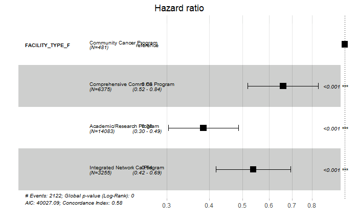

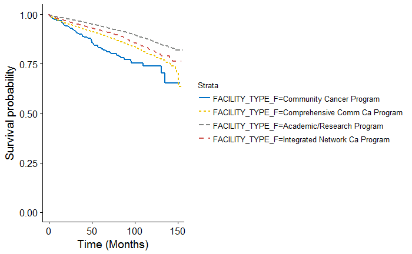

```r
uni_var(test_var = "FACILITY_TYPE_F", data_imp = data)
```

## Facility Location

```
_________________________________________________

## FACILITY_LOCATION_F
_________________________________________________
Call: survfit(formula = Surv(DX_LASTCONTACT_DEATH_MONTHS, PUF_VITAL_STATUS ==
    0) ~ FACILITY_LOCATION_F, data = data)

   3996 observations deleted due to missingness
                                          n events median 0.95LCL 0.95UCL
FACILITY_LOCATION_F=New England        1135     95     NA      NA      NA
FACILITY_LOCATION_F=Middle Atlantic    4365    381     NA      NA      NA
FACILITY_LOCATION_F=South Atlantic     4652    399     NA      NA      NA
FACILITY_LOCATION_F=East North Central 4100    356     NA      NA      NA
FACILITY_LOCATION_F=East South Central 1646    176     NA      NA      NA
FACILITY_LOCATION_F=West North Central 2346    185     NA      NA      NA
FACILITY_LOCATION_F=West South Central 1750    160     NA      NA      NA
FACILITY_LOCATION_F=Mountain           1374    140     NA      NA      NA
FACILITY_LOCATION_F=Pacific            2826    230     NA      NA      NA

Call: survfit(formula = Surv(DX_LASTCONTACT_DEATH_MONTHS, PUF_VITAL_STATUS ==
    0) ~ FACILITY_LOCATION_F, data = data)

3996 observations deleted due to missingness
                FACILITY_LOCATION_F=New England
 time n.risk n.event survival std.err lower 95% CI upper 95% CI
   12   1051      13    0.988 0.00327        0.982        0.995
   24    959      12    0.976 0.00469        0.967        0.986
   36    811       9    0.966 0.00569        0.955        0.978
   48    693      13    0.950 0.00721        0.936        0.964
   60    558      12    0.932 0.00878        0.915        0.949
  120     93      34    0.825 0.02126        0.784        0.868

                FACILITY_LOCATION_F=Middle Atlantic
 time n.risk n.event survival std.err lower 95% CI upper 95% CI
   12   3961      94    0.978 0.00228        0.973        0.982
   24   3522      54    0.964 0.00292        0.958        0.970
   36   2997      45    0.951 0.00348        0.944        0.958
   48   2461      32    0.940 0.00396        0.932        0.947
   60   1958      34    0.925 0.00462        0.916        0.934
  120    339     106    0.831 0.01039        0.811        0.852
```

[output cut: 89 more lines]

```
                                      exp(coef) exp(-coef) lower .95 upper .95
FACILITY_LOCATION_FMiddle Atlantic       1.0831     0.9233    0.8651     1.356
FACILITY_LOCATION_FSouth Atlantic        0.9567     1.0453    0.7649     1.197
FACILITY_LOCATION_FEast North Central    1.0658     0.9382    0.8499     1.337
FACILITY_LOCATION_FEast South Central    1.2898     0.7753    1.0049     1.655
FACILITY_LOCATION_FWest North Central    0.8650     1.1561    0.6753     1.108
FACILITY_LOCATION_FWest South Central    1.0792     0.9266    0.8372     1.391
FACILITY_LOCATION_FMountain              1.1329     0.8827    0.8730     1.470
FACILITY_LOCATION_FPacific               0.9540     1.0483    0.7511     1.212

Concordance= 0.524  (se = 0.007 )
Rsquare= 0.001   (max possible= 0.81 )
Likelihood ratio test= 20.86  on 8 df,   p=0.007522
Wald test            = 21.09  on 8 df,   p=0.006925
Score (logrank) test = 21.19  on 8 df,   p=0.006657
```

```
Removed 1 rows containing missing values (geom_errorbar).
```

```
## Unadjusted Kaplan Meier Overall Survival Curve for:  FACILITY_LOCATION_F
```

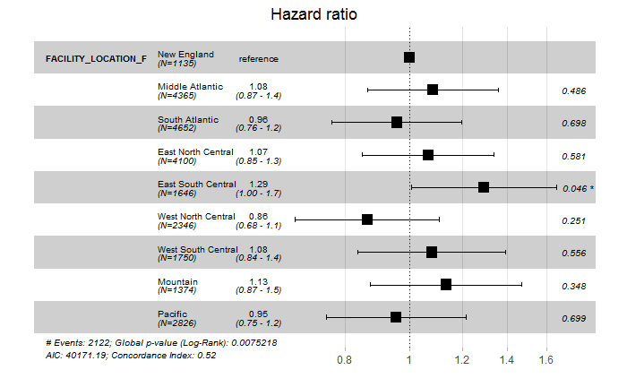

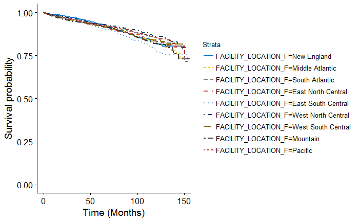

```r
uni_var(test_var = "FACILITY_LOCATION_F", data_imp = data)
```

## Facility Geography

```
_________________________________________________

## FACILITY_GEOGRAPHY
_________________________________________________
Call: survfit(formula = Surv(DX_LASTCONTACT_DEATH_MONTHS, PUF_VITAL_STATUS ==
    0) ~ FACILITY_GEOGRAPHY, data = data)

   3996 observations deleted due to missingness
                                n events median 0.95LCL 0.95UCL
FACILITY_GEOGRAPHY=Northeast 5500    476     NA      NA      NA
FACILITY_GEOGRAPHY=South     6402    559     NA      NA      NA
FACILITY_GEOGRAPHY=Midwest   8092    717     NA      NA      NA
FACILITY_GEOGRAPHY=West      4200    370     NA      NA      NA

Call: survfit(formula = Surv(DX_LASTCONTACT_DEATH_MONTHS, PUF_VITAL_STATUS ==
    0) ~ FACILITY_GEOGRAPHY, data = data)

3996 observations deleted due to missingness
                FACILITY_GEOGRAPHY=Northeast
 time n.risk n.event survival std.err lower 95% CI upper 95% CI
   12   5012     107    0.980 0.00193        0.976        0.984
   24   4481      66    0.966 0.00251        0.962        0.971
   36   3808      54    0.954 0.00300        0.948        0.960
   48   3154      45    0.942 0.00348        0.935        0.948
   60   2516      46    0.926 0.00409        0.918        0.934
  120    432     140    0.830 0.00937        0.812        0.848

                FACILITY_GEOGRAPHY=South
 time n.risk n.event survival std.err lower 95% CI upper 95% CI
   12   5976     122    0.980 0.00175        0.977        0.984
   24   5424      78    0.967 0.00228        0.963        0.972
   36   4678      70    0.954 0.00275        0.949        0.959
   48   3992      69    0.939 0.00325        0.932        0.945
   60   3332      50    0.926 0.00368        0.919        0.933
  120    618     152    0.848 0.00749        0.834        0.863

                FACILITY_GEOGRAPHY=Midwest
 time n.risk n.event survival std.err lower 95% CI upper 95% CI
   12   7464     161    0.980 0.00160        0.976        0.983
   24   6644      89    0.967 0.00204        0.963        0.971
```

[output cut: 27 more lines]

```
                              coef exp(coef) se(coef)      z Pr(>|z|)
FACILITY_GEOGRAPHYSouth   -0.07448   0.92823  0.06239 -1.194    0.233
FACILITY_GEOGRAPHYMidwest -0.01663   0.98351  0.05914 -0.281    0.779
FACILITY_GEOGRAPHYWest    -0.04865   0.95251  0.06933 -0.702    0.483

                          exp(coef) exp(-coef) lower .95 upper .95
FACILITY_GEOGRAPHYSouth      0.9282      1.077    0.8214     1.049
FACILITY_GEOGRAPHYMidwest    0.9835      1.017    0.8759     1.104
FACILITY_GEOGRAPHYWest       0.9525      1.050    0.8315     1.091

Concordance= 0.503  (se = 0.007 )
Rsquare= 0   (max possible= 0.81 )
Likelihood ratio test= 1.77  on 3 df,   p=0.6223
Wald test            = 1.76  on 3 df,   p=0.6235
Score (logrank) test = 1.76  on 3 df,   p=0.6234
```

```
Removed 1 rows containing missing values (geom_errorbar).
```

```
## Unadjusted Kaplan Meier Overall Survival Curve for:  FACILITY_GEOGRAPHY
```

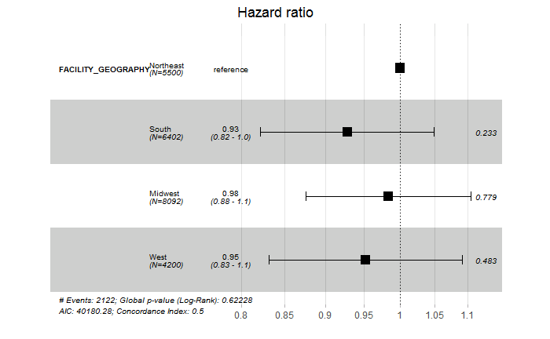

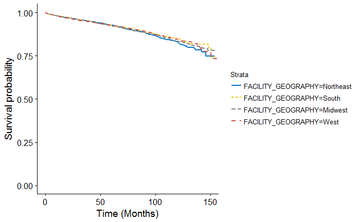

```r
uni_var(test_var = "FACILITY_GEOGRAPHY", data_imp = data)
```

## Age Group

```
_________________________________________________

## AGE_F
_________________________________________________
Call: survfit(formula = Surv(DX_LASTCONTACT_DEATH_MONTHS, PUF_VITAL_STATUS ==
    0) ~ AGE_F, data = data)

   5 observations deleted due to missingness
                   n events median 0.95LCL 0.95UCL
AGE_F=(0,54]   12867    323     NA      NA      NA
AGE_F=(54,64]   7647    398     NA      NA      NA
AGE_F=(64,74]   5068    620     NA      NA      NA
AGE_F=(74,100]  2603    858    105     101     113

Call: survfit(formula = Surv(DX_LASTCONTACT_DEATH_MONTHS, PUF_VITAL_STATUS ==
    0) ~ AGE_F, data = data)

5 observations deleted due to missingness
                AGE_F=(0,54]
 time n.risk n.event survival  std.err lower 95% CI upper 95% CI
   12  11915      81    0.994 0.000720        0.992        0.995
   24  10714      44    0.990 0.000924        0.988        0.991
   36   9245      43    0.985 0.001127        0.983        0.988
   48   7883      27    0.982 0.001274        0.980        0.985
   60   6578      25    0.979 0.001435        0.976        0.982
  120   1410     100    0.951 0.003286        0.945        0.958

                AGE_F=(54,64]
 time n.risk n.event survival std.err lower 95% CI upper 95% CI
   12   7114      99    0.987 0.00133        0.984        0.989
   24   6401      53    0.979 0.00169        0.976        0.982
   36   5557      41    0.972 0.00197        0.968        0.976
   48   4662      43    0.964 0.00231        0.960        0.969
   60   3811      29    0.958 0.00260        0.953        0.963
  120    731     113    0.904 0.00593        0.893        0.916

                AGE_F=(64,74]
 time n.risk n.event survival std.err lower 95% CI upper 95% CI
   12   4664     125    0.975 0.00224        0.970        0.979
   24   4123      87    0.956 0.00298        0.950        0.962
```

[output cut: 29 more lines]

```
AGE_F(64,74]   1.67440   5.33558  0.06866 24.388   <2e-16 ***
AGE_F(74,100]  2.79783  16.40899  0.06545 42.750   <2e-16 ***
---
Signif. codes:  0 *** 0.001 ** 0.01 * 0.05 . 0.1   1

              exp(coef) exp(-coef) lower .95 upper .95
AGE_F(54,64]      2.113    0.47326     1.825     2.447
AGE_F(64,74]      5.336    0.18742     4.664     6.104
AGE_F(74,100]    16.409    0.06094    14.434    18.655

Concordance= 0.751  (se = 0.006 )
Rsquare= 0.078   (max possible= 0.777 )
Likelihood ratio test= 2298  on 3 df,   p=0
Wald test            = 2312  on 3 df,   p=0
Score (logrank) test = 3491  on 3 df,   p=0
```

```
Removed 1 rows containing missing values (geom_errorbar).
```

```
## Unadjusted Kaplan Meier Overall Survival Curve for:  AGE_F
```

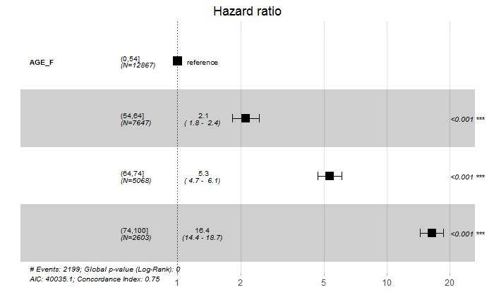

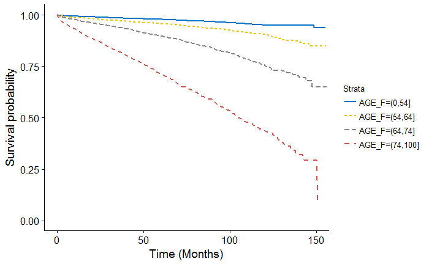

```r
uni_var(test_var = "AGE_F", data_imp = data)
```

## Age Group

```
_________________________________________________

## AGE_40
_________________________________________________
Call: survfit(formula = Surv(DX_LASTCONTACT_DEATH_MONTHS, PUF_VITAL_STATUS ==
    0) ~ AGE_40, data = data)

   5 observations deleted due to missingness
                    n events median 0.95LCL 0.95UCL
AGE_40=(0,40]    4345     87     NA      NA      NA
AGE_40=(40,100] 23840   2112     NA      NA      NA

Call: survfit(formula = Surv(DX_LASTCONTACT_DEATH_MONTHS, PUF_VITAL_STATUS ==
    0) ~ AGE_40, data = data)

5 observations deleted due to missingness
                AGE_40=(0,40]
 time n.risk n.event survival std.err lower 95% CI upper 95% CI
   12   3987      27    0.994 0.00123        0.991        0.996
   24   3531       9    0.991 0.00147        0.988        0.994
   36   3022      11    0.988 0.00178        0.984        0.991
   48   2546       6    0.986 0.00197        0.982        0.990
   60   2119       7    0.983 0.00224        0.978        0.987
  120    445      27    0.963 0.00469        0.953        0.972

                AGE_40=(40,100]
 time n.risk n.event survival  std.err lower 95% CI upper 95% CI
   12  21986     472    0.980 0.000929        0.978        0.981
   24  19704     299    0.966 0.001214        0.963        0.968
   36  16889     248    0.953 0.001451        0.950        0.956
   48  14176     232    0.939 0.001701        0.935        0.942
   60  11572     192    0.925 0.001950        0.921        0.929
  120   2235     597    0.837 0.004152        0.829        0.846





## Univariable Cox Proportional Hazard Model for:  AGE_40

Call:
coxph(formula = Surv(DX_LASTCONTACT_DEATH_MONTHS, PUF_VITAL_STATUS ==
    0) ~ AGE_40, data = data)

  n= 28185, number of events= 2199
   (5 observations deleted due to missingness)

                 coef exp(coef) se(coef)     z Pr(>|z|)
AGE_40(40,100] 1.4838    4.4097   0.1094 13.56   <2e-16 ***
---
Signif. codes:  0 *** 0.001 ** 0.01 * 0.05 . 0.1   1

               exp(coef) exp(-coef) lower .95 upper .95
AGE_40(40,100]      4.41     0.2268     3.559     5.464

Concordance= 0.556  (se = 0.004 )
Rsquare= 0.011   (max possible= 0.777 )
Likelihood ratio test= 298.4  on 1 df,   p=0
Wald test            = 184  on 1 df,   p=0
Score (logrank) test = 220.3  on 1 df,   p=0
```

```
Removed 1 rows containing missing values (geom_errorbar).
```

```
## Unadjusted Kaplan Meier Overall Survival Curve for:  AGE_40
```

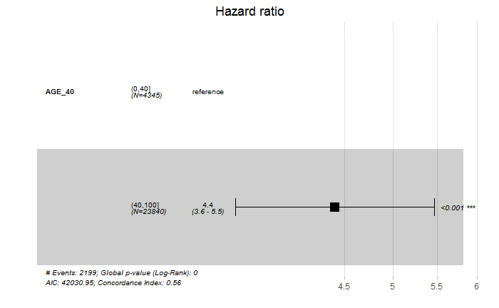

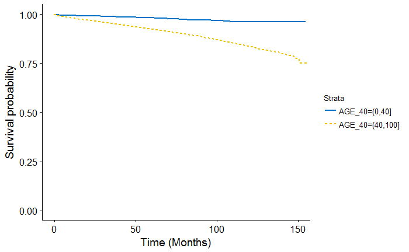

```r
uni_var(test_var = "AGE_40", data_imp = data)
```

## Gender

```
_________________________________________________

## SEX_F
_________________________________________________
Call: survfit(formula = Surv(DX_LASTCONTACT_DEATH_MONTHS, PUF_VITAL_STATUS ==
    0) ~ SEX_F, data = data)

                 n events median 0.95LCL 0.95UCL
SEX_F=Male   13276   1122     NA      NA      NA
SEX_F=Female 14914   1077     NA      NA      NA

Call: survfit(formula = Surv(DX_LASTCONTACT_DEATH_MONTHS, PUF_VITAL_STATUS ==
    0) ~ SEX_F, data = data)

                SEX_F=Male
 time n.risk n.event survival std.err lower 95% CI upper 95% CI
   12  12151     262    0.980 0.00125        0.977        0.982
   24  10764     157    0.966 0.00162        0.963        0.969
   36   9230     120    0.955 0.00191        0.951        0.959
   48   7713     131    0.940 0.00227        0.936        0.945
   60   6296     107    0.926 0.00262        0.921        0.931
  120   1216     311    0.844 0.00548        0.833        0.854

                SEX_F=Female
 time n.risk n.event survival std.err lower 95% CI upper 95% CI
   12  13827     237    0.984 0.00105        0.982        0.986
   24  12475     151    0.973 0.00138        0.970        0.975
   36  10685     139    0.961 0.00168        0.958        0.964
   48   9013     107    0.950 0.00194        0.947        0.954
   60   7397      92    0.940 0.00221        0.936        0.944
  120   1465     313    0.866 0.00484        0.857        0.876





## Univariable Cox Proportional Hazard Model for:  SEX_F

Call:
coxph(formula = Surv(DX_LASTCONTACT_DEATH_MONTHS, PUF_VITAL_STATUS ==
    0) ~ SEX_F, data = data)

  n= 28190, number of events= 2199

                coef exp(coef) se(coef)      z Pr(>|z|)
SEX_FFemale -0.18930   0.82754  0.04266 -4.437 9.11e-06 ***
---
Signif. codes:  0 *** 0.001 ** 0.01 * 0.05 . 0.1   1

            exp(coef) exp(-coef) lower .95 upper .95
SEX_FFemale    0.8275      1.208    0.7612    0.8997

Concordance= 0.525  (se = 0.006 )
Rsquare= 0.001   (max possible= 0.777 )
Likelihood ratio test= 19.69  on 1 df,   p=9.124e-06
Wald test            = 19.69  on 1 df,   p=9.105e-06
Score (logrank) test = 19.75  on 1 df,   p=8.829e-06
```

```
Removed 1 rows containing missing values (geom_errorbar).
```

```
## Unadjusted Kaplan Meier Overall Survival Curve for:  SEX_F
```

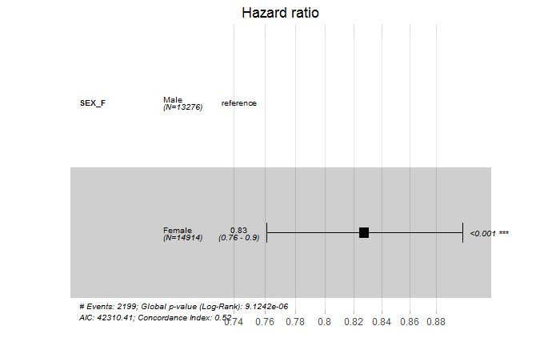

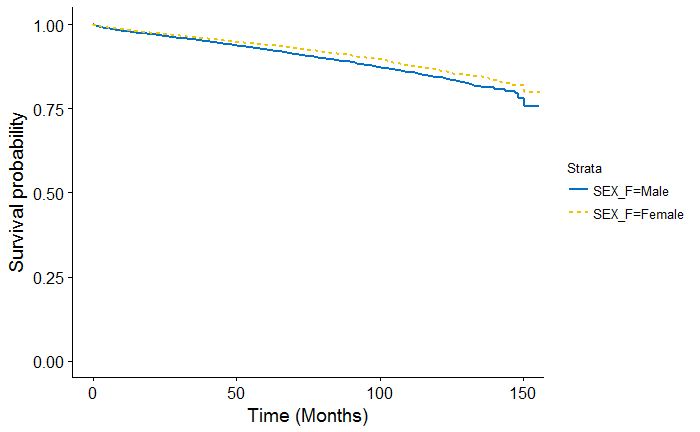

```r
uni_var(test_var = "SEX_F", data_imp = data)
```

## RACE_F

```
_________________________________________________

## RACE_F
_________________________________________________
Call: survfit(formula = Surv(DX_LASTCONTACT_DEATH_MONTHS, PUF_VITAL_STATUS ==
    0) ~ RACE_F, data = data)

                     n events median 0.95LCL 0.95UCL
RACE_F=White     24720   1966     NA      NA      NA
RACE_F=Black      1248    122     NA      NA      NA
RACE_F=Other/Unk  1364     66     NA      NA      NA
RACE_F=Asian       858     45     NA      NA      NA

Call: survfit(formula = Surv(DX_LASTCONTACT_DEATH_MONTHS, PUF_VITAL_STATUS ==
    0) ~ RACE_F, data = data)

                RACE_F=White
 time n.risk n.event survival std.err lower 95% CI upper 95% CI
   12  22834     444    0.981 0.00087        0.980        0.983
   24  20443     276    0.969 0.00113        0.967        0.971
   36  17520     235    0.957 0.00136        0.955        0.960
   48  14740     212    0.945 0.00159        0.942        0.948
   60  12069     174    0.933 0.00182        0.929        0.936
  120   2417     559    0.855 0.00385        0.847        0.862

                RACE_F=Black
 time n.risk n.event survival std.err lower 95% CI upper 95% CI
   12   1137      32    0.974 0.00460        0.965        0.983
   24   1005      12    0.963 0.00551        0.952        0.974
   36    855      15    0.947 0.00673        0.934        0.961
   48    708      14    0.931 0.00793        0.915        0.946
   60    570      15    0.909 0.00956        0.890        0.928
  120     86      33    0.810 0.02044        0.771        0.851

                RACE_F=Other/Unk
 time n.risk n.event survival std.err lower 95% CI upper 95% CI
   12   1230      12    0.991 0.00266        0.986        0.996
   24   1120      11    0.982 0.00383        0.974        0.989
   36    973       3    0.979 0.00414        0.971        0.987
   48    836       8    0.970 0.00513        0.960        0.980
```

[output cut: 26 more lines]

```
RACE_FOther/Unk -0.48526   0.61554  0.12514 -3.878 0.000105 ***
RACE_FAsian     -0.30362   0.73814  0.15078 -2.014 0.044050 *
---
Signif. codes:  0 *** 0.001 ** 0.01 * 0.05 . 0.1   1

                exp(coef) exp(-coef) lower .95 upper .95
RACE_FBlack        1.3174     0.7591    1.0972    1.5818
RACE_FOther/Unk    0.6155     1.6246    0.4816    0.7866
RACE_FAsian        0.7381     1.3547    0.5493    0.9919

Concordance= 0.52  (se = 0.004 )
Rsquare= 0.001   (max possible= 0.777 )
Likelihood ratio test= 31.12  on 3 df,   p=8.027e-07
Wald test            = 28.89  on 3 df,   p=2.36e-06
Score (logrank) test = 29.38  on 3 df,   p=1.867e-06
```

```
Removed 1 rows containing missing values (geom_errorbar).
```

```
## Unadjusted Kaplan Meier Overall Survival Curve for:  RACE_F
```

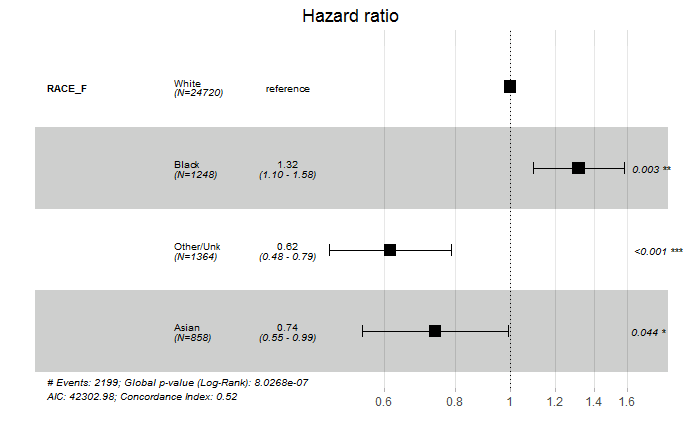

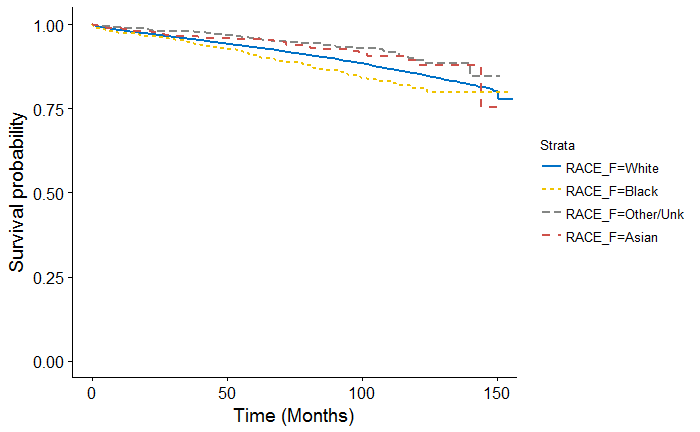

```r
uni_var(test_var = "RACE_F", data_imp = data)
```

## Hispanic

```
_________________________________________________

## HISPANIC
_________________________________________________
Call: survfit(formula = Surv(DX_LASTCONTACT_DEATH_MONTHS, PUF_VITAL_STATUS ==
    0) ~ HISPANIC, data = data)

                     n events median 0.95LCL 0.95UCL
HISPANIC=No      24750   1964     NA      NA      NA
HISPANIC=Yes      1320     73     NA      NA      NA
HISPANIC=Unknown  2120    162     NA      NA      NA

Call: survfit(formula = Surv(DX_LASTCONTACT_DEATH_MONTHS, PUF_VITAL_STATUS ==
    0) ~ HISPANIC, data = data)

                HISPANIC=No
 time n.risk n.event survival  std.err lower 95% CI upper 95% CI
   12  22875     434    0.982 0.000859        0.980        0.984
   24  20412     277    0.970 0.001126        0.967        0.972
   36  17435     236    0.958 0.001358        0.955        0.960
   48  14565     210    0.945 0.001591        0.942        0.948
   60  11852     178    0.932 0.001829        0.929        0.936
  120   2306     562    0.852 0.003957        0.844        0.860

                HISPANIC=Yes
 time n.risk n.event survival std.err lower 95% CI upper 95% CI
   12   1178      21    0.983 0.00359        0.976        0.990
   24   1041      13    0.972 0.00477        0.963        0.981
   36    865       9    0.963 0.00561        0.952        0.974
   48    715      10    0.951 0.00670        0.938        0.964
   60    584       5    0.943 0.00742        0.929        0.958
  120     90      15    0.889 0.01620        0.858        0.921

                HISPANIC=Unknown
 time n.risk n.event survival std.err lower 95% CI upper 95% CI
   12   1925      44    0.978 0.00323        0.972        0.985
   24   1786      18    0.969 0.00388        0.961        0.977
   36   1615      14    0.961 0.00438        0.953        0.970
   48   1446      18    0.950 0.00507        0.940        0.960
   60   1257      16    0.939 0.00575        0.927        0.950
```

[output cut: 14 more lines]

```
                   coef exp(coef) se(coef)      z Pr(>|z|)
HISPANICYes     -0.2706    0.7629   0.1192 -2.270   0.0232 *
HISPANICUnknown -0.1728    0.8413   0.0818 -2.113   0.0346 *
---
Signif. codes:  0 *** 0.001 ** 0.01 * 0.05 . 0.1   1

                exp(coef) exp(-coef) lower .95 upper .95
HISPANICYes        0.7629      1.311    0.6040    0.9637
HISPANICUnknown    0.8413      1.189    0.7167    0.9876

Concordance= 0.507  (se = 0.004 )
Rsquare= 0   (max possible= 0.777 )
Likelihood ratio test= 9.72  on 2 df,   p=0.007752
Wald test            = 9.14  on 2 df,   p=0.01034
Score (logrank) test = 9.18  on 2 df,   p=0.01013
```

```
Removed 1 rows containing missing values (geom_errorbar).
```

```
## Unadjusted Kaplan Meier Overall Survival Curve for:  HISPANIC
```

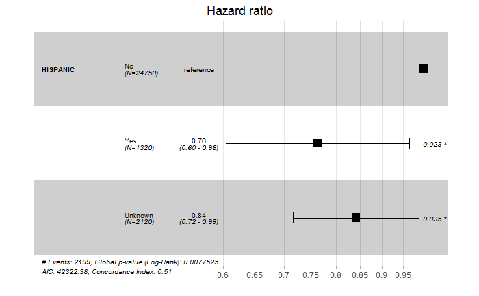

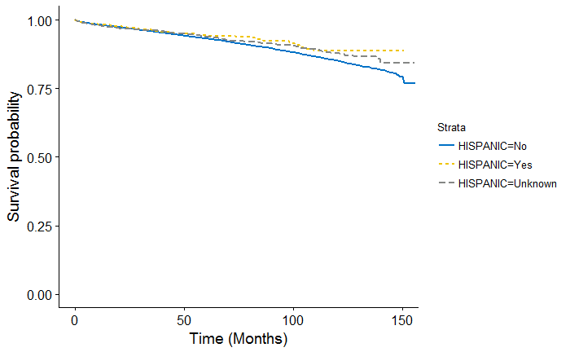

```r
uni_var(test_var = "HISPANIC", data_imp = data)
```

## Insurance Status

```
_________________________________________________

## INSURANCE_F
_________________________________________________
Call: survfit(formula = Surv(DX_LASTCONTACT_DEATH_MONTHS, PUF_VITAL_STATUS ==
    0) ~ INSURANCE_F, data = data)

                                 n events median 0.95LCL 0.95UCL
INSURANCE_F=Private          17766    619     NA      NA      NA
INSURANCE_F=None               589     41     NA      NA      NA
INSURANCE_F=Medicaid          1212    101     NA      NA      NA
INSURANCE_F=Medicare          7394   1349    150     147      NA
INSURANCE_F=Other Government   580     35     NA      NA      NA
INSURANCE_F=Unknown            649     54     NA      NA      NA

Call: survfit(formula = Surv(DX_LASTCONTACT_DEATH_MONTHS, PUF_VITAL_STATUS ==
    0) ~ INSURANCE_F, data = data)

                INSURANCE_F=Private
 time n.risk n.event survival  std.err lower 95% CI upper 95% CI
   12  16544     141    0.992 0.000686        0.990        0.993
   24  14953      69    0.987 0.000858        0.986        0.989
   36  12944      72    0.982 0.001044        0.980        0.984
   48  11014      62    0.977 0.001220        0.975        0.980
   60   9146      56    0.972 0.001416        0.969        0.975
  120   1893     199    0.934 0.003189        0.928        0.940

                INSURANCE_F=None
 time n.risk n.event survival std.err lower 95% CI upper 95% CI
   12    519      15    0.973 0.00688        0.960        0.987
   24    459       5    0.963 0.00816        0.947        0.979
   36    385       5    0.952 0.00949        0.933        0.970
   48    333       3    0.943 0.01052        0.923        0.964
   60    262       3    0.934 0.01170        0.912        0.957
  120     43       9    0.848 0.03192        0.788        0.913

                INSURANCE_F=Medicaid
 time n.risk n.event survival std.err lower 95% CI upper 95% CI
   12   1085      26    0.978 0.00433        0.969        0.986
   24    909      19    0.959 0.00602        0.947        0.971
```

[output cut: 50 more lines]

```
---
Signif. codes:  0 *** 0.001 ** 0.01 * 0.05 . 0.1   1

                            exp(coef) exp(-coef) lower .95 upper .95
INSURANCE_FNone                 2.259     0.4426     1.647     3.099
INSURANCE_FMedicaid             2.885     0.3466     2.338     3.561
INSURANCE_FMedicare             5.922     0.1689     5.384     6.514
INSURANCE_FOther Government     2.076     0.4816     1.477     2.919
INSURANCE_FUnknown              2.222     0.4501     1.682     2.934

Concordance= 0.705  (se = 0.006 )
Rsquare= 0.051   (max possible= 0.777 )
Likelihood ratio test= 1480  on 5 df,   p=0
Wald test            = 1364  on 5 df,   p=0
Score (logrank) test = 1724  on 5 df,   p=0
```

```
Removed 1 rows containing missing values (geom_errorbar).
```

```
## Unadjusted Kaplan Meier Overall Survival Curve for:  INSURANCE_F
```

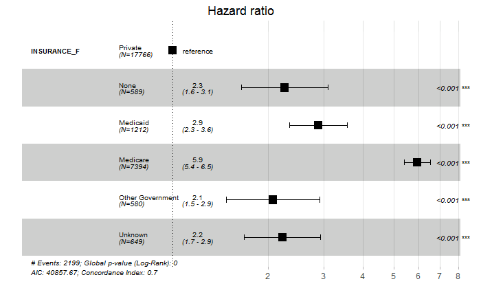

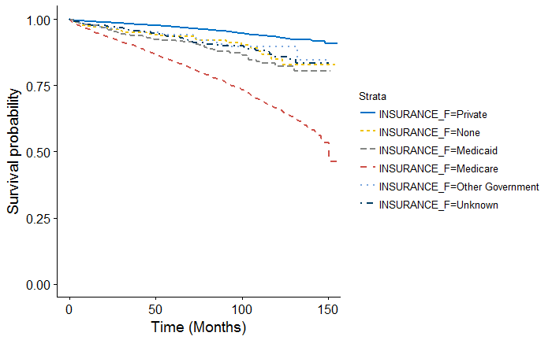

```r
uni_var(test_var = "INSURANCE_F", data_imp = data)
```

## Income

```
_________________________________________________

## INCOME_F
_________________________________________________
Call: survfit(formula = Surv(DX_LASTCONTACT_DEATH_MONTHS, PUF_VITAL_STATUS ==
    0) ~ INCOME_F, data = data)

   217 observations deleted due to missingness
                               n events median 0.95LCL 0.95UCL
INCOME_F=Less than $38,000  3406    331     NA      NA      NA
INCOME_F=$38,000 - $47,999  5864    541     NA      NA      NA
INCOME_F=$48,000 - $62,999  7961    623     NA      NA      NA
INCOME_F=$63,000 +         10742    670     NA      NA      NA

Call: survfit(formula = Surv(DX_LASTCONTACT_DEATH_MONTHS, PUF_VITAL_STATUS ==
    0) ~ INCOME_F, data = data)

217 observations deleted due to missingness
                INCOME_F=Less than $38,000
 time n.risk n.event survival std.err lower 95% CI upper 95% CI
   12   3110      74    0.977 0.00259        0.972        0.983
   24   2768      38    0.965 0.00325        0.959        0.971
   36   2379      33    0.953 0.00387        0.945        0.960
   48   1987      40    0.935 0.00468        0.926        0.944
   60   1609      30    0.920 0.00539        0.909        0.930
  120    320     108    0.815 0.01137        0.793        0.837

                INCOME_F=$38,000 - $47,999
 time n.risk n.event survival std.err lower 95% CI upper 95% CI
   12   5386     124    0.978 0.00193        0.974        0.982
   24   4778      84    0.962 0.00257        0.957        0.967
   36   4106      67    0.948 0.00307        0.942        0.954
   48   3456      55    0.934 0.00354        0.927        0.941
   60   2839      44    0.921 0.00399        0.914        0.929
  120    593     148    0.837 0.00813        0.821        0.853

                INCOME_F=$48,000 - $62,999
 time n.risk n.event survival std.err lower 95% CI upper 95% CI
   12   7323     123    0.984 0.00143        0.981        0.987
   24   6567      90    0.971 0.00193        0.968        0.975
```

[output cut: 29 more lines]

```
INCOME_F$48,000 - $62,999 -0.21962   0.80283  0.06802 -3.229  0.00124 **
INCOME_F$63,000 +         -0.46498   0.62815  0.06719 -6.921 4.49e-12 ***
---
Signif. codes:  0 *** 0.001 ** 0.01 * 0.05 . 0.1   1

                          exp(coef) exp(-coef) lower .95 upper .95
INCOME_F$38,000 - $47,999    0.9353      1.069    0.8157    1.0724
INCOME_F$48,000 - $62,999    0.8028      1.246    0.7026    0.9173
INCOME_F$63,000 +            0.6281      1.592    0.5506    0.7166

Concordance= 0.547  (se = 0.006 )
Rsquare= 0.002   (max possible= 0.774 )
Likelihood ratio test= 69.8  on 3 df,   p=4.663e-15
Wald test            = 68.87  on 3 df,   p=7.438e-15
Score (logrank) test = 69.71  on 3 df,   p=4.885e-15
```

```
Removed 1 rows containing missing values (geom_errorbar).
```

```
## Unadjusted Kaplan Meier Overall Survival Curve for:  INCOME_F
```

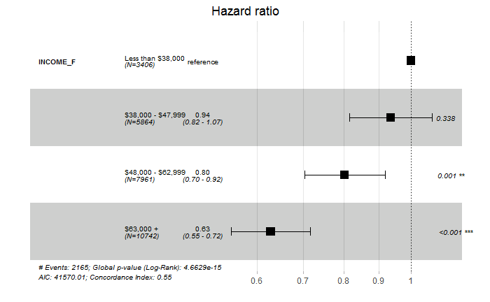

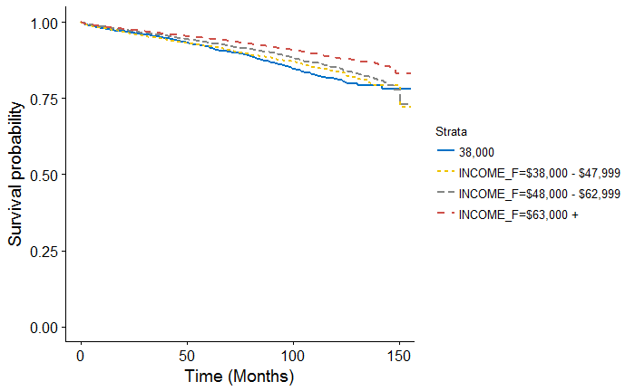

```r
uni_var(test_var = "INCOME_F", data_imp = data)
```

## Education

```
_________________________________________________

## EDUCATION_F
_________________________________________________
Call: survfit(formula = Surv(DX_LASTCONTACT_DEATH_MONTHS, PUF_VITAL_STATUS ==
    0) ~ EDUCATION_F, data = data)

   206 observations deleted due to missingness
                            n events median 0.95LCL 0.95UCL
EDUCATION_F=21% or more  3276    309     NA      NA      NA
EDUCATION_F=13 - 20.9%   6186    546     NA      NA      NA
EDUCATION_F=7 - 12.9%    9685    747     NA      NA      NA
EDUCATION_F=Less than 7% 8837    563     NA      NA      NA

Call: survfit(formula = Surv(DX_LASTCONTACT_DEATH_MONTHS, PUF_VITAL_STATUS ==
    0) ~ EDUCATION_F, data = data)

206 observations deleted due to missingness
                EDUCATION_F=21% or more
 time n.risk n.event survival std.err lower 95% CI upper 95% CI
   12   2990      81    0.974 0.00280        0.969        0.980
   24   2675      41    0.960 0.00351        0.954        0.967
   36   2258      32    0.948 0.00410        0.940        0.956
   48   1896      30    0.934 0.00477        0.925        0.943
   60   1518      32    0.917 0.00558        0.906        0.928
  120    285      82    0.829 0.01117        0.808        0.851

                EDUCATION_F=13 - 20.9%
 time n.risk n.event survival std.err lower 95% CI upper 95% CI
   12   5701     120    0.980 0.00181        0.976        0.984
   24   5082      75    0.967 0.00235        0.962        0.971
   36   4373      70    0.952 0.00288        0.947        0.958
   48   3676      60    0.938 0.00335        0.932        0.945
   60   2999      46    0.926 0.00380        0.918        0.933
  120    583     161    0.845 0.00748        0.830        0.860

                EDUCATION_F=7 - 12.9%
 time n.risk n.event survival std.err lower 95% CI upper 95% CI
   12   8917     150    0.984 0.00130        0.981        0.987
   24   7989     109    0.971 0.00175        0.968        0.975
```

[output cut: 29 more lines]

```
EDUCATION_F7 - 12.9%    -0.22810   0.79605  0.06764 -3.372 0.000746 ***
EDUCATION_FLess than 7% -0.43652   0.64628  0.07080 -6.165 7.04e-10 ***
---
Signif. codes:  0 *** 0.001 ** 0.01 * 0.05 . 0.1   1

                        exp(coef) exp(-coef) lower .95 upper .95
EDUCATION_F13 - 20.9%      0.9114      1.097    0.7927    1.0479
EDUCATION_F7 - 12.9%       0.7960      1.256    0.6972    0.9089
EDUCATION_FLess than 7%    0.6463      1.547    0.5625    0.7425

Concordance= 0.542  (se = 0.007 )
Rsquare= 0.002   (max possible= 0.774 )
Likelihood ratio test= 50.73  on 3 df,   p=5.581e-11
Wald test            = 50.2  on 3 df,   p=7.258e-11
Score (logrank) test = 50.67  on 3 df,   p=5.761e-11
```

```
Removed 1 rows containing missing values (geom_errorbar).
```

```
## Unadjusted Kaplan Meier Overall Survival Curve for:  EDUCATION_F
```

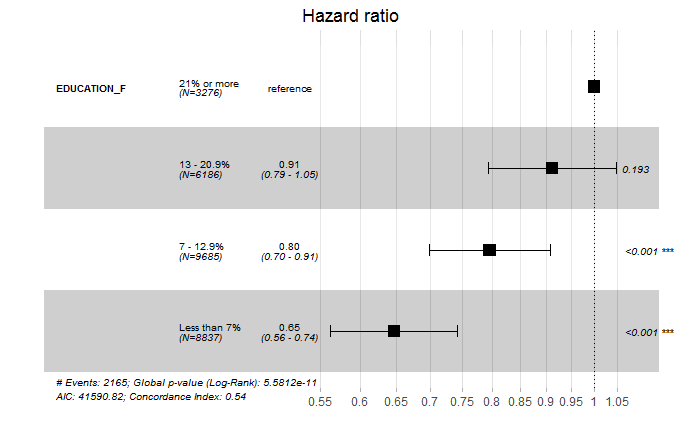

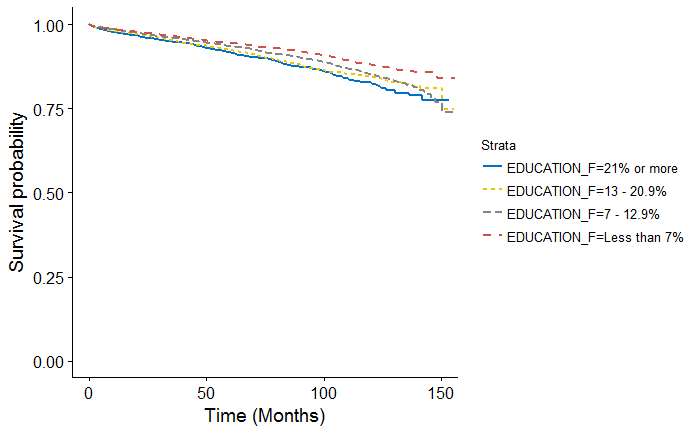

```r
uni_var(test_var = "EDUCATION_F", data_imp = data)
```